[figure not shown]

# Introduction to Python for Data Science

# Lecture 05: Flow Control

## Student Name: Live HTML Testing

## Student ID: NA

## 0.1.0 About Introduction to Python

Introduction to Python is brought to you by the **Centre for the Analysis of Genome Evolution & Function (CAGEF)** bioinformatics training initiative. This course was developed based on feedback on the needs and interests of the Department of Cell & Systems Biology and the Department of Ecology and Evolutionary Biology.

The structure of this course is a code-along style so it is 100% hands on! A few hours prior to each lecture, the materials will be avaialable for download at [QUERCUS](https://q.utoronto.ca/). The teaching materials will consist of a Jupyter Lab Notebook with concepts, comments, instructions, and blank spaces that you will fill out with Python code along with the instructor. Other teaching materials include a live version of the notebook, and datasets to import into Python - when required. This learning approach will allow you to spend the time coding and not taking notes!

As we go along, there will be some in-class challenge questions for you to solve either individually or in cooperation with your peers. Post lecture assessments will also be available (see syllabus for grading scheme and percentages of the final mark) through [DataCamp](https://Datacamp.com) to help cement and/or extend what you learn each week.

### 0.1.1 Where is this course headed?

We'll take a blank slate approach here to Python and assume that you pretty much know *nothing* about programming. From the beginning of this course to the end, we want to get you from some potential scenarios:

- A pile of data (like an excel file or tab-separated file) full of experimental observations and you don't know what to do with it.
- Maybe you're manipulating large tables all in excel, making custom formulas and pivot table with graphs. Now you have to repeat similar experiments and do the analysis again.
- You're generating high-throughput data and there aren't any bioinformaticians around to help you sort it out.
- You heard about Python and what it *could* do for your data analysis but don't know what that means or where to start.

and get you to a point where you can:

- Format your data correctly for analysis
- Produce basic plots and perform exploratory analysis
- Make functions and scripts for re-analysing existing or new data sets
- Track your experiments in a digital notebook like Jupyter!

### 0.1.2 How do we get there? Step-by-step.

In the first two lessons, we will talk about the basic data structures and objects in Python, get cozy with the Jupyter Notebook environment, and learn how to get help when you are stuck. Because everyone gets stuck - a lot! Then you will learn how to get your data in and out of Python, how to tidy our data (data wrangling), subset and merge data. We'll take a break from data wrangling to spend our fourth lecture learning how to generate exploratory data plots. Then we'll slide into using the power of python and programming to use flow control before visiting text manipulation techniques in lectures 5 and 6. Data cleaning and string manipulation is really the battleground of coding - getting your data into the format where you can analyse it. Lastly, we will learn to write customized functions to help scale up your analyses.

[figure not shown]

The structure of the class is a **code-along** style: It is fully hands on. At the end of each lecture, the complete notes will be made available in a PDF format through the corresponding Quercus module so you don't have to spend your attention on taking notes.

### 0.1.3 What kind of coding style will we learn?

There is no single path correct from A to B - although some paths may be more elegant, or more efficient than others. With that in mind, the emphasis in this lecture series will be on:

1. **Code simplicity** - learn helpful functions that allow you to focus on understanding the basic tenets of good data wrangling (reformatting) to facilitate quick exploratory data analysis and visualization.
2. **Code readability** - format and comment your code for yourself and others so that even those with minimal experience in R will be able to quickly grasp the overall steps in your code.
3. **Code stability** - while the core Python code is relatively stable, behaviours of functions can still change with updates. There are well-developed packages we'll focus on for our analyses. Namely, we'll become more familiar with the `pandas` series of packages for working with tabular data. This resource is well-maintained by a large community of developers. While not always the "fastest" approach this additional layer can help ensure your code still runs (somewhat) smoothly later down the road.

## 0.2.0 Lecture objectives

Welcome to this fifth lecture in a series of seven. Today we're going to branch off into the wonderful world of flow control and how you can really make your code work for you.

At the end of this lecture we will aim to have covered the following topics:

1. What is flow control?
2. Logical, conditional, and comparison operators
3. For Loops
4. Conditional Loops

## 0.3.0 A legend for text format in Jupyter markdown

`grey background` - a package, function, code, command or directory. Backticks are also use for in-line code.  
*italics* - an important term or concept or an individual file or folder  
**bold** - heading or a term that is being defined  
blue text - named or unnamed hyperlink

`...` - Within each coding cell this will indicate an area of code that students will need to complete for the code cell to run correctly.

**Blue box:** A key concept that is being introduced

**Yellow box:** Risk or caution

**Green boxes:** Recommended reads and resources to learn Python

**Red boxes:** A comprehension question which may or may not involve a coding cell. You usually find these at the end of a section.

## 0.4.0 Lecture and data files used in this course

### 0.4.1 Weekly Lecture and skeleton files

Each week, new lesson files will appear within your JupyterHub folders. We are pulling from a GitHub repository using this [Repository git-pull link](https://jupyter.utoronto.ca/hub/user-redirect/git-pull?repo=https%3A%2F%2Fgithub.com%2Fcamok%2F2024-01-IntroPython&urlpath=tree%2F2024-01-IntroPython%2F&branch=main). Simply click on the link and it will take you to the University of Toronto JupyterHub. You will need to use your UTORid credentials to complete the login process. From there you will find each week's lecture files in the directory `/2024-01-IntroPython/Lecture_XX`. You will find a partially coded `skeleton.ipynb` file as well as all of the data files necessary to run the week's lecture.

Alternatively, you can download the Jupyter Notebook (`.ipynb`) and data files from JupyterHub to your personal computer if you would like to run independently of the JupyterHub.

### 0.4.2 Live-coding HTML page

A live lecture version will be available at [camok.github.io](https://camok.github.io/2024-01.IntroPython/index.html) that will update as the lecture progresses. Be sure to refresh to take a look if you get lost!

### 0.4.3 Post-lecture PDFs

As mentioned above, at the end of each lecture there will be a completed version of the lecture code released as a PDF file under the Modules section of Quercus.

### 0.4.4 Microsporidia infection data set description

The following datasets used in this week's class come from a published manuscript on PLoS Pathogens entitled "High-throughput phenotyping of infection by diverse microsporidia species reveals a wild *C. elegans* strain with opposing resistance and susceptibility traits" by [Mok et al., 2023](https://journals.plos.org/plospathogens/article?id=10.1371/journal.ppat.1011225). These datasets focus on the an analysis of infection in wild isolate strains of the nematode *C. elegans* by environmental pathogens known as microsporidia. The authors collected embryo counts from individual animals in the population after population-wide infection by microsporidia and we'll spend our next few classes working with the dataset to learn how to format and manipulate it.

### 0.4.4.1 Dataset 1: /data/embryo_long_merged.csv

This is a result of our efforts (mostly) from **lecture 3**. After transforming a wide-format version of our measurement data, we merged it with some metadata regarding our experiments and now it is ready to be worked with.

## 0.5.0 Packages used in this lesson

`IPython` and `InteractiveShell` will be access just to set the behaviour we want for iPython so we can see multiple code outputs per code cell.

`numpy` provides a number of mathematical functions as well as the special data class of `arrays` which we'll be learning about today.

`pandas` provides the DataFrame class that allows us to format and play with data in a tabular format.

`time` provides various time-related functions.

```python
# ----- Always run this at the beginning of class so we can get multi-command output ----- #

# Access options from the iPython core
from IPython.core.interactiveshell import InteractiveShell

# Change the value of ast_node_interactivity
InteractiveShell.ast_node_interactivity = "all"

# ----- Additional packages we want to import for class ----- #

# We need numpy to work with values in an element-wise manner
import numpy as np

# Import the pandas package
import pandas as pd

# Import the seaborn visualization package
import seaborn as sns
```

# 1.0.0 What is flow control and why is it important?

Flow controls are programs that allow us to repeat a task over and over until there are no more iterations to perform or until a condition that we set is not met anymore. This means that, with a few lines of code, you can perform tasks that otherwise require you copying/pasting your code hundreds or thousands of times.

Flow control is one of the most important skills to have in your computer programming toolbox. All programming languages use them and while the logic behind them is very similar, the syntax to write the code differs. Under the hood of Python, its packages, methods and functions all have some form of flow control implemented - especially in the cases where it seems like a single command is accomplishing a lot.

Having a good understanding of data subsetting, logical, conditional, and comparison operators, is critical to writing flow control programs. Thus, we will start off this lecture with a recap of some those concepts from previous lecture.

| Comparing the use of flow control for a program or scripts vs a linear sequence of code. Image from https://codewithlogic.wordpress.com/2013/09/01/python-basics-understanding-the-flow-control-statemen… |
| --- |

## 1.1.0 The benefits of flow control

As we saw last week, for instance, we were able to take advantage of the `groupby()` method to organize our DataFrame data based on categories. We may wish, for instance to look at these groups individually to decide if they merit further analysis or visualization. If your number of groups is rather small, you could manually curate this data. When dealing with much larger data sets, it would be in your best interests to *automate* this using the ideas of flow control.

In the above example, we would describe the process as **iterating** through your DataFrame. At each iteration you are using a **branching statement** to determine if a primary or secondary analysis should be performed. We'll learn throughout this lecture that there are a number of syntax patterns used to `iterate` or `loop` through your data as well as a number of predefined forms of `conditional` or `branching` statements. Here are some helpful tables to summarize what we'll cover today:

| flow control method | Description | Syntax |
| --- | --- | --- |
| for loop | Used to iterate through a range, list, or other iterable data structure from start to end. | for item in iterable: statement |
| while loop | Used to iterate through a range, list, or other iterable data structure as long as a conditional expression remains true at the start of each iteration. | while condition: statement |
| if | Begin a branching statement to runs specific code if a conditional is met. | if condition: statement |
| elif | Used to extend the if statement as an alternative condition/action pairing. | elif condition: statement |

[output not shown]

# 2.0.0 Logical, conditional, and comparison operators recap

One key aspect about these type of operators is that their output is boolean (`True` or `False`), and those outputs can be used to perform a wide range of operations. Here are some comparison operators.

## 2.1.0 Logical operators

We've already seen the logical operators in previous lectures. They're used to generate logical expressions that we use to filter values or set conditions for further steps. We'll even use these to determine the branching of code (ie Control of flow). Here's a table briefly summarizing these operators:

| Operator | Description |
| --- | --- |
| > | Greater than |
| >= | Greater than or equal to |
| < | Less than |
| <= | Less than or equal to |
| == | Equivalent values (but not necessarily equivalent objects in memory |
| != | Inequality or dissimilar values |

These are quite straight-forward to work with for integers or floats.

```python
# Less than
5 < 3

# Equivalent
10 == 9

# Dissimilar
24 != 24

# Less than or equal to
8 <= 15
```

```
False
```

```
False
```

```
False
```

```
True
```

### 2.1.1 Logical operators can evaluate strings

The rules for using logical operators on strings is slightly different versus integers. When comparing strings, the following procedure is followed:

1. Characters are compared by matching indices between strings
2. When characters are not equivalent, their Unicode value is compared
3. The character with the lower Unicode value is considered to be smaller
4. The longer string is considered larger when the character values are equal.

Here's a Unicode table to help us out with our interpretation.

| Notice the placement of upper case vs lower case letters? The ASCII values for upper case are smaller! |
| --- |

Let's give it a try shall we?

```python
# Can a string be less than itself?
"carrot" < "carrot"

# What about Capitalization? C < c
"Carrot" < "carrot"
```

```
False
```

```
True
```

```python
# Remember matching indices are evaluated one at a time! a > A
"Carrot" < "CArrot"

# Does overall Unicode "value" matter?
"Barrot" < "CARROT"
```

```
False
```

```
True
```

```python
# All things equal, a longer string is bigger
"CARROTcake" < "CARROT"

# But it still evaluates each index positions first
"BARROTcake" < "CARROT"

# What about just adding a space?
"CARROT " == "CARROT"
```

```
False
```

```
True
```

```
False
```

### 2.1.2 Don't forget: values being compared must be of the same type

We've seen that we can compare integers with integers and how strings can be compared but we can't simply compare dissimilar object types. So no comparing apples to sheep - they just don't stack up.

Throughout our lectures we've seen plenty of similar situations where we tried to use multi-purpose operators like `+` on combinations of strings and integers. However, these types of objects are not comparable in their native state.

If you need to compare strings and numeric values for some odd reason, you can cast one to match the other - where applicable.

```python
# What if we cast a string to an int? or vice versa?

int("5") < 4

str(4) < "5"

# You can't cast a complex string to an integer
int("car") < 4
```

```
False
```

```
True
```

```
---------------------------------------------------------------------------
ValueError                                Traceback (most recent call last)
Cell In[7], line 8
      5 str(4) < "5"
      7 # You can't cast a complex string to an integer
----> 8 int("car") < 4

ValueError: invalid literal for int() with base 10: 'car'
```

### 2.1.3 For element-wise comparison, use an `array`

Recall that the `numpy.array` object has the ability to broadcast operations and perform element-wise mathematical expressions on like-sized arrays. The same applies to conditional expression. By converting our list of numbers to an `array` object, we can perform conditional expressions against a scalar (single value) or against other arrays. The output, of course, is a boolean array of the original size.

Note that when comparing arrays, both must be of the same size (index-index comparison), or one must be of length 1 (all-by-one comparison).

The comparison will return an array of booleans giving the element-wise answers.

```python
# Needs to be a numpy array to compare to a single integer (array adds element-wise capability)

var = np.array([1, 4, 6, 9])

var > 10

# and right side must be of length 1 or have the same shape
var < [3, 4, 6, 3]
```

```
array([False, False, False, False])
```

```
array([ True, False, False, False])
```

## 2.2.0 Boolean operators

Last week we briefly disucssed the boolean operators when filtering our DataFrames based on specific criteria in particular columns. To revisit, the boolean operators are used for combining `True` and `False` values that can come in various formats. Boolean operators can be used to combine logical expressions, variables, or both. **In base Python**, we have four operators at our disposal to combine or compare boolean (logical) and non-boolean (bitwise) values.

| Operator | Description | Evaluation rules | Works with np.array? |
| --- | --- | --- | --- |
| **and** | Logical AND results in True only when all comparisons are True | True and True = True | No. |
|  |  | True and False = False |  |
|  |  | False and False = False |  |
| **&** | Bitwise AND compares the binary values of an integer at every bit | 1010 1010 & 0101 0101 = 0000 0000 | **Yes** |
| **or** | Logical OR results in False only when all comparisons are False | True or True = True | No |
|  |  | True or False = True |  |
|  |  | False or False = False |  |
| **\|** | Bitwise OR compares the binary values of an integer at every bit | 1010 1010 \| 0101 0101 = 1111 1111 | **Yes** |

Recall that integers can be converted to booleans with any value other than 0 being considered as `True`. So we can also use bitwise comparison on these booleans although `and` and `or` are more appropriate. The `and` and `or` operators should be restricted to combining *single* boolean values.

Note also that the logical operators (`<`, `>`, `==`, etc.) take a higher order precedence than `and` and `not` when being evaluated within an expression. Conversely bitwise `&` and `|` take higher precedence than the logical operators so appropriate use of parentheses `()` will be required.

**Element-wise boolean combination:** Look closely at the tables and notice that the bitwise **&** and **|** operators are used for element-wise comparison in the **np.array** and therefore also the **DataFrame** or **Series** objects.

Let's try our hand at using `and` and `or` to combine simple conditional boolean statements.

```python
# Testing logical AND

True and True # True and True = True

4 < 6 and 4< 8 # True and True = True

4 > 6 and 7 < 8 # False and True = False

4 > 6 and 7 > 8 # False and False = False

4 < 6 and 7 > 8 # True and False = False
```

```
True
```

```
True
```

```
False
```

```
False
```

```
False
```

```python
# Testing logical OR

True or True # True or True = True

4 < 6 or 4 < 8 # True or True = True

4 > 6 or 7 < 8 # False or True = True

4 > 6 or 7 > 8 # False or False = False

4 < 6 or 7 > 8 # True or False = True
```

```
True
```

```
True
```

```
True
```

```
False
```

```
True
```

```python
# Create a series of boolean arrays
bool_array1 = np.array([False, True, True, False])
bool_array2 = np.array([True, True, False, False])

# element-wise AND = FTFF
bool_array1 & bool_array2

# element-wise OR = TTTF
bool_array1 | bool_array2

# Compress boolean arrays into a single value using .any() or .all()
bool_array1.any() and bool_array2.any()
```

```
array([False,  True, False, False])
```

```
array([ True,  True,  True, False])
```

```
True
```

### 2.2.1 Use the logical `not` to negate your boolean values

The final operator we'll review is the logical NOT. This is a *unary* operator that can evaluate a **single input** and returns the opposite boolean value to that input. This can be used to negate the boolean evaluation from a logical expression. This can be especially useful when generating conditional statements that will determine which parts of your code are run (ie control of flow).

```python
# Simple case of using not
not False # True

# You can even use it on integers
not 1 # False

not 0 # True
```

```
True
```

```
False
```

```
True
```

```python
# Reverse the result of a logical result
not 7 > 8 # True

not 7 < 8 # False: 7 IS less than 8

# A more complex case with mixed operands
not(7 < 8 and 5 < 4) # not(True AND False) = not(False) = True

not(7 < 8 and 4 < 5) # not(True AND True) = not(True) = False
```

```
True
```

```
False
```

```
True
```

```
False
```

### 2.2.2 The logical `not` can be used on non-boolean objects

Beware: the logical `not` does not apply across all types of objects.

However, a quick and easy way to determine the status of an object is to use the logical `not`. It will return `False` **unless the object is empty**. This can also be a very useful way to determine if a variable has been assigned to a proper object.

```python
 # Try an empty string
not ''
# vs a character or string
not 'a'

# How does the logical NOT handle a list?
[True, False, True, False, False]

# NOT our list
not [False, False, False, False, False]

# What about any kind of list?
not [1, 2, 3]

# Perhaps an empty list?
not []
```

```
True
```

```
False
```

```
[True, False, True, False, False]
```

```
False
```

```
False
```

```
True
```

| There are a number of ways to obtain the same boolean result! |
| --- |

Here ends the recap on logical operators. Time to loop! But first...

**Section 2.0.0 Comprehension Question:** What is the result of using a bit-wise AND on the numbers 5 and 3? What about bit-wise OR on 12 and 7? Use the code cell below to help you work out your answers.

```python
# Use this code cell to answer the above comprehension questions.
```

# 3.0.0 Time for `for` loops

`for` loops allow you to iteratively perform operations or data manipulation. Their general structure is

```
for item in iterable:
     statement
```

In the above general structure:

- `iterable` is a Python data structure that contains your data, and can be a `list`, an `array`, a `DataFrame`, etc.
- `item` is the iteration variable, and will take the form of each element that you are iterating over.
- `statement` is the set of instructions (addition, multiplication, evaluations, etc.) that you want to perform - usually over `iterable`.

In plain English, it means something like "for every `item` in `iterable`, do `statement` until you reach the last element in `iterable`.

The last thing to note is the indentation on this for loop. Up until now, we have not really been using any tabbed indentation style in our coding **unless** we have extended parentheses `()` around our statements. Normally we use tabbed indentation to *help* make our code more readable ie by indenting the `statements` inside a for loop.

Python takes this philosophy to the next step by **requiring indentation-as-grammar** of statements within a control flow structure to be considered part of that structure. We'll see what that means in upcoming examples.

Here are a some definitions of concepts that we will be using today:

**Iteration:** the repetition of a sequence of computer instructions a specified number of times or until a condition is met<sup>1</sup>.

**Iterator:** An iterator is an object that contains a countable number of values that can be iterated upon, meaning that you can traverse through all the values<sup>2</sup>.

**Iterable:** Is an object that has an **iter** method which returns an iterator.

<sup>1</sup>https://www.merriam-webster.com/dictionary, <sup>2</sup>https://www.w3schools.com/python/python_iterators.asp

## 3.1.0 Looping over data structures

There are several structures that are iterable, including core Python data structures such as lists, tuples, dictionaries, sets, and the non-core structures such as multidimensional Numpy Arrays and Pandas DataFrames. *They are all iterable objects*. They are iterable *containers* because you can retrieve iterators from them (https://www.w3schools.com/python/python_iterators.asp).

### 3.1.1 Iterators

The job of iterators is to create a "count" or "index" of the elements over which you want to iterate, thus creating a road map to loop over an iterable (a data structure). There are several functions that are meant to be iterators or that can also work as iterators, and which one to use varies with the program that you want to write and what iterator you are working with. Here are some of the most common iterators in Python:

| Function | Syntax | Description | Examples/Requirements |
| --- | --- | --- | --- |
| enumerate() | enumerate(iterable, start) | Return an `enumerate` object which yields pairs containing a count from `start` (default 0) and a value yielded by the iterable argument. Useful for obtaining and indexed list. | `iterable` must be another object that supports iteration. |
| range() | range(start, stop[, step]) | Return an object that **produces a sequence of integers** from `start` (inclusive) to `stop` (exclusive) by `step` (optional). | `range(i, j)` produces i, i+1, i+2, ..., j-1. |
|  |  |  | `range(4)` produces 0,1,2,3. |
| iter() | iter(iterable) or | Get an iterator from an object. In the first form, the argument must supply its own iterator, or be a sequence. |  |
|  | iter(callable, sentinel) | In the second form, the callable is called until it returns the sentinel. | A callable is an object that allows you to use round parenthesis ( ). A sentinel value is a condition that indicates the termination of a recursive algorithm. |
| numpy.ndenumerate() | numpy.ndenumerate(arr) | Multidimensional index iterator. Return an iterator yielding pairs of array coordinates and values. |  |
| numpy.ndindex() | numpy.ndindex(*shape) | An N-dimensional iterator object to index arrays. Given the shape of an array, an `ndindex` instance iterates over the N-dimensional index of the array. At each iteration a tuple of indices is returne… |  |
| numpy.nditer() | numpy.nditer(np.array) | Efficient multi-dimensional iterator object to iterate over arrays. To get started using this object, you can visit this [helpful tutorial](https://numpy.org/doc/1.20/reference/arrays.nditer.html#arra… |  |

```python
# enumerate?
# range?
# iter?
# import numpy as np
# np.ndenumerate?
# np.ndindex?
# np.nditer?
```

That's a lot of functions to digest! Let's step back and break down iteration by looking at the different data structures we know.

## 3.2.0 Iterating through lists

The built-in `list` structure represents a mutable structure that you will likely work with often and thus iterate through. Note that the for loop is setting the variable `listVal` to the element value in the list at each *iteration*. We are **not** assigning an index position to the variable `listVal`.

Let's *iterate* through some examples.

```python
# For loop on a simple list
for listVal in [1,2,3]:
    print("This is an integer:", listVal)

print("done!") # Note the indentation of this print() call?
```

```
This is an integer: 1
This is an integer: 2
This is an integer: 3
done!
```

```python
# Generate a list assigned to a variable
list_1 =[1, 2, 3]

# Loop through a variable
for listVal in list_1:
    print("This is an integer:", listVal)

print("done!")
```

```
This is an integer: 1
This is an integer: 2
This is an integer: 3
done!
```

### 3.2.1 Use loops to increment a counter

Sometimes you might want to count the number of iterations that occur within a loop. This may be part of some branching code that we'll look at later. With a simple version of such code you can answer, for example, "how many odd integers are in my list?.

Let's see how a loop can be used to increment a variable's value.

```python
# we need to initialize the counter at 0 outside of our loop
count = 0

for item in list_1:
    count = count + 1
    print("item value:", item)

print("Final count value:", count)
```

```
item value: 1
item value: 2
item value: 3
Final count value: 3
```

Replace 1 by 30, and **item** by **count** in the print function, and run the code again. What do you think this code is doing?

```python
 # We need to initialize the counter at 0 outside of our loop
count = 0

for item in list_1:
    count = count + 30
    print('Count:', count)
```

```
Count: 30
Count: 60
Count: 90
```

### 3.2.2 Sum the elements of a list with a `for` loop

Cumulative summation can be done through for loops although we also have the `sum()` function to accomplish that. Do you wonder how the `sum()` function actually works?

```python
sum_list = [3, 41, 12, 9, 74, 15]

# Take the sum of this list
print("sum() function:", sum(sum_list), "\n")

total = 0

for item in sum_list:
    # in this case we use item (iteration variable)
    total = total + item
    # Print the total with each loop
    print("Updating total:", total)

print('\nFor loop total:', total)
```

```
sum() function: 154

Updating total: 3
Updating total: 44
Updating total: 56
Updating total: 65
Updating total: 139
Updating total: 154

For loop total: 154
```

### 3.2.3 Subset using the assigned `iterable` variable in your loop

Recall we stated earlier that when we use the `for` loop, the iterator, by design, is returning each *element* of the `iterable`. This make sense for a list but sometimes you want to use or keep the index position of your list as you work with it.

Therefore you cannot *always* apply your `iterator` variable as a method for subsetting/indexing the same object or a similar-sized one - especially for a list. Remember to index a list, you'll need an integer! However, to index a dictionary object, you must provide a non-integer key value. The context really determines what will work in your code.

Let's look at the following example and what could go wrong if you try to iterate through a list by assigning your `iterator` as an index value.

```python
# Make a list of integers
list_2 = [1, 2, 3, 4, 5]

# Use our integer list in our for loop
for x in list_2:
    # Subset our integer list using the values from it
    print(list_2[x])
```

```
2
3
4
5
```

```
---------------------------------------------------------------------------
IndexError                                Traceback (most recent call last)
Cell In[24], line 7
      4 # Use our integer list in our for loop
      5 for x in list_2:
      6     # Subset our integer list using the values from it
----> 7     print(list_2[x])

IndexError: list index out of range
```

### 3.2.4 Use the `range()` function as a for loop interator

Look at what happened above. We ended up accessing an element outside the range of the indices in our list. Even though we had a sequence set of integers, we started at `1` and lists are **zero-indexed**. Simply using the values from the list isn't the correct way to iterate through it either. What we really want is a list of integer values starting at 0 and going to the length of our list.

Recall from previous lectures that we can use the `range()` function to create an `iterable` object for a series of values. The default behaviour when unary input is provided, is to calculate (0, stop] where we use `(` to denote inclusivity and `]` to denote exclusivity.

How will you retrieve the length of your list so you know how to set your range? Let's take a look at the approach for iterating a list of strings by *index*.

```python
# Set up a list of strings
photosynthesis_types = ['C3', 'C4', 'CAM', 'Anoxygenic', 'Oxygenic']

# Cacluate the length of our list
len(photosynthesis_types)

# How to properly use range
range(len(photosynthesis_types))

# What object does it return?
type(range(len(photosynthesis_types)))
```

```
5
```

```
range(0, 5)
```

```
range
```

Now we can substitute our `range` object as the iterable into our for loop. Let's only take **the last 3 elements**.

```python
# Remember range takes in an integer value as input
for x in range(2, len(photosynthesis_types)):
    # Print the values of our iterator
    print(x)
    # Print the values indexed from our list
    print(photosynthesis_types[x])
```

```
2
CAM
3
Anoxygenic
4
Oxygenic
```

Note that the last code cell requires some knowledge about the size of our list as we generate a range from 2 to len(photosynthesis_types). We only know to begin at 2 because we know the length! Remember there's a better way to accomplish this by indexing using negative values!

```python
# Build a range from -3 to 0!
for x in range(-3, 0):
    # Print the values of our iterator
    print(x)
    # Print the values indexed from our list
    print(photosynthesis_types[x])
```

```
-3
CAM
-2
Anoxygenic
-1
Oxygenic
```

It works! The loop has an index to iterate ("from 0 to the last item")

So to summarize, we've used a `for` loop:

- to assign list elements directly to a variable
- with an iterator to subset elements from a list
  - To subset from a list, we need a representation of it's *indices*.
  - Use the `range(start, len(list))` combination to achieve an iterable set of indices.

What about other data structures?

## 3.3.0 Looping over one-dimensional Numpy arrays

Recall that Numpy arrays are not built-in data structures. While they share a lot of visual and conceptual similarities to Python `list` objects they are not the same. Instead they include functions for generating iterators from these `Numpy` objects. As a note, all packages that produce iterable objects should include basic methods like `__iter__` that Python expects to find when provided to something like a `for` loop.

A `numpy.array` object returns an `iterator` that behaves very much like a list so each invididual element is returned in the iterator. That being said, there can be differences in the behaviours between objects and these factors can influence how you should write your code.

Recall that just like a list, the `np.array` can't be accessed by index values outside its own bounds. Doing so will cause an error, which means we have to use the same approach as we did with generating a `range` object for lists.

```python
# 1d numpy array
array_1 = np.array([1,2,3,4,5])

array_1
```

```
array([1, 2, 3, 4, 5])
```

```python
# Iterate through a for loop using the array_1 iterator
for i in array_1:
    # Just print the entire array
    print(array_1)
```

```
[1 2 3 4 5]
[1 2 3 4 5]
[1 2 3 4 5]
[1 2 3 4 5]
[1 2 3 4 5]
```

```python
# Iterate through elements of the array by index
for i in range(len(array_1)):
    # Print the elements from array_1. What will happen here?
    print(array_1[i])
```

```
1
2
3
4
5
```

### 3.3.1 Arrays and loops can be combined for broadcasting

Remember that arrays are data structures designed for broadcasting. That means we can do things like multiply across elements, replace or fill multiple elements at once (in the case of DataFrames).

Let's create a for loop that multiplies the *first four* digits of `array_1` by 4. Store each iteration in an object called `iteration_result`.

```python
# Two ways to access the first 4 digits of our array
array_1 = np.array([0,1,2,3,4,5])

# The long way around! Take the length of the array but then only the first four elements.
for i in range(len(array_1))[0:4]:
    iteration_result = array_1[i] * 4
    print(iteration_result)
```

```
0
4
8
12
```

```python
# Knowing you only want the first 4 elements, why not just make a proper range?
for i in range(4):
    iteration_result = array_1[i] * 4
    print(iteration_result)
```

```
0
4
8
12
```

### 3.3.2 Obtain *multiple* iterators with the `nditer()` function

So far we've only been generating a single iterator using the base behaviours of the `for` loop. However, we can use functions that return *multiple* iterables to us. In turn that can provide multiple iterators to a loop after assigning them to variables. This idea also occurs when converting `dictionary.items()` to an iterator (**See Section 6: Appendix 1**).

For the `numpy` package, we have a way to produce multiple iterables with the `np.nditer()` function. It can take in one or more `array` objects and return iterables for each - in the form of a `tuple` OR as separate iterables.

**Why use multiple iterables in a loop?** The advantage of this comes in pairing multiple sets of information together by their indices. In doing so you can complete element-wise comparisons. That sounds *familiar* right? Remember, we're working in the realm of **arrays** and these are the kind of things you might want to do often like comparing one array of data to another!

```python
# Make a second array, also with 6 elements
array_2 = np.array([6, 7, 8, 9, 10, 11])

array_1
array_2

for x, y in np.nditer([array_1, array_2]):

    # This includes a little bit of string formatting magic that we'll discuss in an upcoming lecture
    print("%d:%d" % (x,y), end = " ")
```

```
array([0, 1, 2, 3, 4, 5])
```

```
array([ 6,  7,  8,  9, 10, 11])
```

```
0:6 1:7 2:8 3:9 4:10 5:11
```

### 3.3.3 Use `nditer()` to help broadcast between dissimilar array sizes

Another feature for `nditer()` is in how it handles the production of iterators for multidimentional arrays and the idea of broadcasting. Suppose instead of two 1x6 arrays, one of our arrays was two-dimensional? With arrays and the right coding, we can broadcast across rows. Just be sure the *row sizes* are the same or you'll receive an error.

In the case of dissimlar-sized arrays, the loop will go over the smaller array, one element at at time, until it completes the iterator, before starting at the beginning again.

```python
# Make a 1D array of values 6-23, then reformat the shape to 3x6
array_3 = np.array(np.arange(6, 24)).reshape(3,6)

array_1
array_3

# We know that array_1 and array_3 are not the same size but they do share the same width dimension
for x, y in np.nditer([array_1, array_3]):
    # We'll broadcast in a row-wise manner
    print("%d:%d" % (x,y), end = " ")
```

```
array([0, 1, 2, 3, 4, 5])
```

```
array([[ 6,  7,  8,  9, 10, 11],
       [12, 13, 14, 15, 16, 17],
       [18, 19, 20, 21, 22, 23]])
```

```
0:6 1:7 2:8 3:9 4:10 5:11 0:12 1:13 2:14 3:15 4:16 5:17 0:18 1:19 2:20 3:21 4:22 5:23
```

```python
# Make just 3 values.
array_4 = np.array(np.arange(0,3))

array_4
array_3

# Will this code recycle our array_1 values?
for x, y in np.nditer([array_4, array_3]):
    print("%d:%d" % (x,y), end = " ")
```

```
array([0, 1, 2])
```

```
array([[ 6,  7,  8,  9, 10, 11],
       [12, 13, 14, 15, 16, 17],
       [18, 19, 20, 21, 22, 23]])
```

```
---------------------------------------------------------------------------
ValueError                                Traceback (most recent call last)
Cell In[35], line 8
      5 array_3
      7 # Will this code recycle our array_1 values?
----> 8 for x, y in np.nditer([array_4, array_3]):
      9     print("%d:%d" % (x,y), end = " ")

ValueError: operands could not be broadcast together with shapes (3,) (3,6)
```

**Iterating over 2D arrays:** While it seems simple enough to iterate over 1D arrays, things can become more complex when working with 2D or higher order arrays. Much of it involves knowing *how* the arrays were originally loaded into memory. To learn more about how this works **AND** how to access elements in memory versus row order, check out **Section 6: Appendix 1**.

## 3.4.0 Looping over Pandas `DataFrames`

We spent the first 3 lectures touching on or working explicitly with `DataFrame` objects. How does looping over these compare to lists, or even arrays? Recall these are 2D structures of tabulated data, suggesting there is organization of some sort across rows and columns.

Let's import `embryo_long_merged.csv` as `data`. As we start looping over the file, we'll also quickly recap on importing and subsetting data frames.

```python
import pandas as pd

# Read in embryo_long_merged.csv
data = pd.read_csv('data/embryo_long_merged.csv')
data.head()
data.info()

# What is the sum of the "Total Worms" column?
data["Total ul spore"].sum()
```

|  | worm.number | date | wormStrain | pathogenStrain | pathogenDose | doseLevel | timepoint | merontsPresent | sporesPresent | numEmbryos | ... | Plate Size | Spores/cm2 | Temp | infection.type | Staining Date | Stain type | Slide date | Slide number | Slide Box | Imaging Date |
| --- | --- | --- | --- | --- | --- | --- | --- | --- | --- | --- | --- | --- | --- | --- | --- | --- | --- | --- | --- | --- | --- |
| 0 | 1 | 190426 | AB1 | LUAm1 | 0M | Mock | 72hpi | False | False | 10 | ... | 6 | 0.0 | 21 | continuous | 190430 | DY96 | 190501 | 7 | 2 | 190502 |
| 1 | 2 | 190426 | AB1 | LUAm1 | 0M | Mock | 72hpi | False | False | 9 | ... | 6 | 0.0 | 21 | continuous | 190430 | DY96 | 190501 | 7 | 2 | 190502 |
| 2 | 3 | 190426 | AB1 | LUAm1 | 0M | Mock | 72hpi | False | False | 16 | ... | 6 | 0.0 | 21 | continuous | 190430 | DY96 | 190501 | 7 | 2 | 190502 |
| 3 | 4 | 190426 | AB1 | LUAm1 | 0M | Mock | 72hpi | False | False | 13 | ... | 6 | 0.0 | 21 | continuous | 190430 | DY96 | 190501 | 7 | 2 | 190502 |
| 4 | 5 | 190426 | AB1 | LUAm1 | 0M | Mock | 72hpi | False | False | 8 | ... | 6 | 0.0 | 21 | continuous | 190430 | DY96 | 190501 | 7 | 2 | 190502 |

5 rows × 31 columns

```
<class 'pandas.core.frame.DataFrame'>
RangeIndex: 11149 entries, 0 to 11148
Data columns (total 31 columns):
 #   Column             Non-Null Count  Dtype
---  ------             --------------  -----
 0   worm.number        11149 non-null  int64
 1   date               11149 non-null  int64
 2   wormStrain         11149 non-null  object
 3   pathogenStrain     11149 non-null  object
 4   pathogenDose       11149 non-null  object
 5   doseLevel          11149 non-null  object
 6   timepoint          11149 non-null  object
 7   merontsPresent     11149 non-null  bool
 8   sporesPresent      11149 non-null  bool
 9   numEmbryos         11149 non-null  int64
```

[output cut: 23 more lines]

```
288946.623161652
```

### 3.4.1 Use `for` loops to import large datasets in smaller chunks

Assuming that you only need to access parts of a file at one time to gather summary information, you can break down large files that will not fit in memory by importing it in smaller chunks. This saves memory and potentially time as you don't have to wait for the whole file to load. Or if information in the file is treated independently between lines or sections - like large sequencing files, you can work with the data in smaller bites.

Luckily for us, the `read_csv()` function has a parameter `chunksize` that we can use to set **how many lines we'd like in each chunk**. By activating this parameter, the function `read_csv()` automatically returns an iterable object called a `TextFileReader`.

```python
# another way to import a large file

# We need a place to put the resulting information
result = []

# Build a for loop by telling the read_csv to break into chunks.
for chunk in pd.read_csv('data/embryo_long_merged.csv', chunksize=100):
    # this operation will be applied to every chunk

    # sum the 'Total ul spore' in every sub-table we import
    # Notice that we are making a list containing the sum within each chunk!
    result.append(sum(chunk['Total ul spore']))

total = sum(result) # sum chunk results in result

print(total)
```

```
288946.62316165236
```

```python
# same as

total = 0 # instead of empty, we initialize with 0 and just add elements to that 0

for chunk in pd.read_csv('data/embryo_long_merged.csv', chunksize=100):

    # += assigns value to total and also appends on every iteration
    total += chunk['Total ul spore'].sum()

print(total)
```

```
288946.6231616521
```

### 3.4.2 The `pd.concat()` function can be used to join DataFrames together

In previous lectures we've explored the `pd.join()` and `pd.merge()` functions to help combine data frames based on common columns. However, sometimes you just want to glue a set of DataFrames together either to add more observations (rows) or variables (columns). To accomplish a simple concatenation of DataFrames, you can use the `pd.concat()` function. Some of its parameters include:

- `objs`: a sequence or mapping of the `Series` or `DataFrames` you want to join. If any are "empty" or `None` objects, then they will be excluded from the concatenation.
- `axis`: the axis to concatenate along (0/index or 1/columns).
- `join`: how to handle indices between the objects being concatenated (ie inner vs outer join)
- `ignore_index`: boolean to determine if a new index should be created (True) vs retaining the original information if it is meaningful in some way (`False`, default).

Here we will use the `pd.concat()` method to grow a `DataFrame` by *rows/index*.

```python
dataLoop = pd.DataFrame()

for chunk in pd.read_csv('data/embryo_long_merged.csv', chunksize=100):
    # Concatenate by rows
    dataLoop = pd.concat([dataLoop, chunk], axis = 0)

dataLoop.info()
```

```
<class 'pandas.core.frame.DataFrame'>
RangeIndex: 11149 entries, 0 to 11148
Data columns (total 31 columns):
 #   Column             Non-Null Count  Dtype
---  ------             --------------  -----
 0   worm.number        11149 non-null  int64
 1   date               11149 non-null  int64
 2   wormStrain         11149 non-null  object
 3   pathogenStrain     11149 non-null  object
 4   pathogenDose       11149 non-null  object
 5   doseLevel          11149 non-null  object
 6   timepoint          11149 non-null  object
 7   merontsPresent     11149 non-null  bool
 8   sporesPresent      11149 non-null  bool
 9   numEmbryos         11149 non-null  int64
```

[output cut: 23 more lines]

### 3.4.3 Review: Subsetting DataFrames

Recall there are a number of ways to subset a DataFrame object. We'll focus mainly on the multi-indexing methods which include:

- `loc[]`: use index and column names in `[row, column]` notation.
- `iloc[]`: use index numbers in `[row, column]` notation.
- `.colName`: access the column names as attributes.

### 3.4.3.1 Additional rules for subsetting DataFrames

1. When using a list `[ ]` within the `loc[]` or `iloc[]` methods for a `DataFrame` object, the resulting object returned will also be a `DataFrame`. Otherwise, it will be a `Series` object.
2. Slicing notation with `:` can be used with `loc[]` and `iloc[]` methods
3. Both `loc[]` and `iloc[]` can accept a boolean `Series` to subset rows from the `DataFrame` as long as the dimensions correctly match.
4. Corollary to (3), you can use a *conditional expression* to filter/subset your data.
5. Corollary to (4), you can *combine* conditional expressions to filter/subset your data.
   - Use logical operators `&` (logical AND) and `|` (logical OR) to combine element-wise.
   - Each conditional expression must be enclosed by parentheses `( )`.
6. The `.query()` method can be used to simplify conditional filtering when using information based on internal column data.

For a brief recap of examples, see **Section 7.0.0: Appendix 2**.

Let's take our current dataset, `data`, and select only data where the **wormStrain** is *N2* that has been infected with pathogen (**doseLevel** is not "Mock").

```python
# Use query() to filter your data by boolean inclusion
N2_infected = data.query('wormStrain == "N2" & doseLevel != "Mock"')

# Compare this to using .loc
# N2_infected = data.loc[(data["wormStrain"] == "N2") &
#                          (data["doseLevel"] != "Mock")]

# Take a peek
N2_infected.head()

# How big is our filtered dataset?
N2_infected.info()
```

|  | worm.number | date | wormStrain | pathogenStrain | pathogenDose | doseLevel | timepoint | merontsPresent | sporesPresent | numEmbryos | ... | Plate Size | Spores/cm2 | Temp | infection.type | Staining Date | Stain type | Slide date | Slide number | Slide Box | Imaging Date |
| --- | --- | --- | --- | --- | --- | --- | --- | --- | --- | --- | --- | --- | --- | --- | --- | --- | --- | --- | --- | --- | --- |
| 2657 | 1 | 190426 | N2 | LUAm1 | 10M | Medium | 72hpi | True | False | 12 | ... | 6 | 0.353857 | 21 | continuous | 190513 | Sp.9 FISH + DY96 | 190515 | 5 | 2 | 190516 |
| 2658 | 2 | 190426 | N2 | LUAm1 | 10M | Medium | 72hpi | True | False | 10 | ... | 6 | 0.353857 | 21 | continuous | 190513 | Sp.9 FISH + DY96 | 190515 | 5 | 2 | 190516 |
| 2659 | 3 | 190426 | N2 | LUAm1 | 10M | Medium | 72hpi | True | False | 10 | ... | 6 | 0.353857 | 21 | continuous | 190513 | Sp.9 FISH + DY96 | 190515 | 5 | 2 | 190516 |
| 2660 | 4 | 190426 | N2 | LUAm1 | 10M | Medium | 72hpi | True | False | 12 | ... | 6 | 0.353857 | 21 | continuous | 190513 | Sp.9 FISH + DY96 | 190515 | 5 | 2 | 190516 |
| 2661 | 5 | 190426 | N2 | LUAm1 | 10M | Medium | 72hpi | True | False | 9 | ... | 6 | 0.353857 | 21 | continuous | 190513 | Sp.9 FISH + DY96 | 190515 | 5 | 2 | 190516 |

5 rows × 31 columns

```
<class 'pandas.core.frame.DataFrame'>
Index: 2221 entries, 2657 to 11148
Data columns (total 31 columns):
 #   Column             Non-Null Count  Dtype
---  ------             --------------  -----
 0   worm.number        2221 non-null   int64
 1   date               2221 non-null   int64
 2   wormStrain         2221 non-null   object
 3   pathogenStrain     2221 non-null   object
 4   pathogenDose       2221 non-null   object
 5   doseLevel          2221 non-null   object
 6   timepoint          2221 non-null   object
 7   merontsPresent     2221 non-null   bool
 8   sporesPresent      2221 non-null   bool
 9   numEmbryos         2221 non-null   int64
```

[output cut: 23 more lines]

Recall that to use element-wise boolean combination, we have 2 rules to follow with `np.array`-like objects which includes DataFrames:

1. Use the bit-wise AND `&`, OR `|` and NOT `~`.
2. Surround your conditional statements by parentheses `( )` if using the `.loc` or `.iloc` methods. This is because of the order of precedence that Python places on various symbols during evaluation of expressions. See **section 2.2.0** for review!

Let's review how that looks:

```python
# Remember order of precedence, you'll need some () to evaluate properly
(N2_infected['numEmbryos'] <= 5) & (N2_infected['numEmbryos'] > 15)
```

```
2657     False
2658     False
2659     False
2660     False
2661     False
         ...
11144    False
11145    False
11146    False
11147    False
11148    False
Name: numEmbryos, Length: 2221, dtype: bool
```

### 3.4.4 Use `numpy.logical_()*` functions as element-wise boolean operators

Another option for us is the function `logical_and()`, `logical_or()` and `logical_not()` to accomplish our task. They have the same behaviour as their Python counterparts (`and`, `or`, and `not`) but are able to properly handle the multi-dimensional data of these objects. Note that these functions are from the `numpy` package!

These functions are also distinguished from the bitwise operators `&` (AND), `|` (OR) and `~` (NOT) mainly by their order of precedence. Remember that these operators will take precedence of evaluation over the logical operands (`<`, `>`, `==`, etc.).

The `logical_*()` functions, however, are given a 2 array-like objects `x1` and `x2` of boolean values over which they will element-wise evaluate the pairs and return a result. These functions are part of the Numpy package and were designed to work specifically with `ndarray` objects. Recall that the `Series` class inherits its behaviours from `ndarray`.

Let's see some follow-up examples.

```python
# Revisit our first example
N2_infected[np.logical_and(N2_infected['numEmbryos'] <= 5,
                           N2_infected['numEmbryos'] > 16)
           ]

# why are we getting an empty dataset?
```

|  | worm.number | date | wormStrain | pathogenStrain | pathogenDose | doseLevel | timepoint | merontsPresent | sporesPresent | numEmbryos | ... | Plate Size | Spores/cm2 | Temp | infection.type | Staining Date | Stain type | Slide date | Slide number | Slide Box | Imaging Date |
| --- | --- | --- | --- | --- | --- | --- | --- | --- | --- | --- | --- | --- | --- | --- | --- | --- | --- | --- | --- | --- | --- |

0 rows × 31 columns

**Getting back empty DataFrames** Whenever we see the above output, it's a good idea to take stock of your code and examine if you are filtering on the criteria you really want to. It may be correct that there are no observations meeting your criteria, but when we filter for something, it's usually because we *expect to see it*.

```python
# Is either one OR the other. What would be a more appropiate function to use in this case?
N2_infected[np.logical_or(N2_infected['numEmbryos'] <= 5,
                          N2_infected['numEmbryos'] > 16)
           ].head()
```

|  | worm.number | date | wormStrain | pathogenStrain | pathogenDose | doseLevel | timepoint | merontsPresent | sporesPresent | numEmbryos | ... | Plate Size | Spores/cm2 | Temp | infection.type | Staining Date | Stain type | Slide date | Slide number | Slide Box | Imaging Date |
| --- | --- | --- | --- | --- | --- | --- | --- | --- | --- | --- | --- | --- | --- | --- | --- | --- | --- | --- | --- | --- | --- |
| 2664 | 8 | 190426 | N2 | LUAm1 | 10M | Medium | 72hpi | True | False | 0 | ... | 6 | 0.353857 | 21 | continuous | 190513 | Sp.9 FISH + DY96 | 190515 | 5 | 2 | 190516 |
| 2665 | 9 | 190426 | N2 | LUAm1 | 10M | Medium | 72hpi | True | False | 0 | ... | 6 | 0.353857 | 21 | continuous | 190513 | Sp.9 FISH + DY96 | 190515 | 5 | 2 | 190516 |
| 2666 | 10 | 190426 | N2 | LUAm1 | 10M | Medium | 72hpi | True | False | 4 | ... | 6 | 0.353857 | 21 | continuous | 190513 | Sp.9 FISH + DY96 | 190515 | 5 | 2 | 190516 |
| 2668 | 12 | 190426 | N2 | LUAm1 | 10M | Medium | 72hpi | True | False | 1 | ... | 6 | 0.353857 | 21 | continuous | 190513 | Sp.9 FISH + DY96 | 190515 | 5 | 2 | 190516 |
| 2669 | 13 | 190426 | N2 | LUAm1 | 10M | Medium | 72hpi | True | False | 0 | ... | 6 | 0.353857 | 21 | continuous | 190513 | Sp.9 FISH + DY96 | 190515 | 5 | 2 | 190516 |

5 rows × 31 columns

Select **N2** observations with less than 10 embryos that DO NOT come from samples infected by the pathogen `ERTm5`.

```python
# Two conditions to fulfill: numEmbryos < 10 and pathogenStrain is not "ERTm5"
N2_infected[np.logical_and(N2_infected['numEmbryos'] < 10,
                           N2_infected['pathogenStrain'] != "ERTm5")
           ]
```

|  | worm.number | date | wormStrain | pathogenStrain | pathogenDose | doseLevel | timepoint | merontsPresent | sporesPresent | numEmbryos | ... | Plate Size | Spores/cm2 | Temp | infection.type | Staining Date | Stain type | Slide date | Slide number | Slide Box | Imaging Date |
| --- | --- | --- | --- | --- | --- | --- | --- | --- | --- | --- | --- | --- | --- | --- | --- | --- | --- | --- | --- | --- | --- |
| 2661 | 5 | 190426 | N2 | LUAm1 | 10M | Medium | 72hpi | True | False | 9 | ... | 6 | 0.353857 | 21 | continuous | 190513 | Sp.9 FISH + DY96 | 190515 | 5 | 2 | 190516 |
| 2662 | 6 | 190426 | N2 | LUAm1 | 10M | Medium | 72hpi | True | False | 8 | ... | 6 | 0.353857 | 21 | continuous | 190513 | Sp.9 FISH + DY96 | 190515 | 5 | 2 | 190516 |
| 2664 | 8 | 190426 | N2 | LUAm1 | 10M | Medium | 72hpi | True | False | 0 | ... | 6 | 0.353857 | 21 | continuous | 190513 | Sp.9 FISH + DY96 | 190515 | 5 | 2 | 190516 |
| 2665 | 9 | 190426 | N2 | LUAm1 | 10M | Medium | 72hpi | True | False | 0 | ... | 6 | 0.353857 | 21 | continuous | 190513 | Sp.9 FISH + DY96 | 190515 | 5 | 2 | 190516 |
| 2666 | 10 | 190426 | N2 | LUAm1 | 10M | Medium | 72hpi | True | False | 4 | ... | 6 | 0.353857 | 21 | continuous | 190513 | Sp.9 FISH + DY96 | 190515 | 5 | 2 | 190516 |
| ... | ... | ... | ... | ... | ... | ... | ... | ... | ... | ... | ... | ... | ... | ... | ... | ... | ... | ... | ... | ... | ... |
| 11144 | 46 | 200916 | N2 | ERTm5-96H | 3.5M | High | 96hpi | True | True | 1 | ... | 6 | 0.123850 | 21 | continuous | 200921 | microB FISH + DY96 | 200921 | 11 | 6 | 201005 |
| 11145 | 47 | 200916 | N2 | ERTm5-96H | 3.5M | High | 96hpi | True | True | 0 | ... | 6 | 0.123850 | 21 | continuous | 200921 | microB FISH + DY96 | 200921 | 11 | 6 | 201005 |
| 11146 | 48 | 200916 | N2 | ERTm5-96H | 3.5M | High | 96hpi | True | True | 0 | ... | 6 | 0.123850 | 21 | continuous | 200921 | microB FISH + DY96 | 200921 | 11 | 6 | 201005 |
| 11147 | 49 | 200916 | N2 | ERTm5-96H | 3.5M | High | 96hpi | True | True | 3 | ... | 6 | 0.123850 | 21 | continuous | 200921 | microB FISH + DY96 | 200921 | 11 | 6 | 201005 |
| 11148 | 50 | 200916 | N2 | ERTm5-96H | 3.5M | High | 96hpi | True | True | 2 | ... | 6 | 0.123850 | 21 | continuous | 200921 | microB FISH + DY96 | 200921 | 11 | 6 | 201005 |

560 rows × 31 columns

**Why use the np.logical_*() functions?** You may wonder, based on our coding, why we would bother to use these functions over the bitwise operators &, | and ~. Both methods seem to take up the same amount of space BUT depending on how complex your conditional is, it might look a little cleaner. There is, however, no technical difference in the evaluation. It is important to note, however, that as you read the code of others, this style may appear from time to time!

That is all for the recap on conditional and logical operators. Back to flow control.

### 3.4.5 The default `for` loop iterator for DataFrames returns column names

How do we print the first 10 observations from the `pathogenStrain` column? We already have a number of routes to arrive at this solution but can we accomplish this using a `for` loop? Let's try the intuitive thing and just provide the DataFrame to the `for` loop first.

```python
# Look at the first 10 rows of data for reference
data.head(10)
```

|  | worm.number | date | wormStrain | pathogenStrain | pathogenDose | doseLevel | timepoint | merontsPresent | sporesPresent | numEmbryos | ... | Plate Size | Spores/cm2 | Temp | infection.type | Staining Date | Stain type | Slide date | Slide number | Slide Box | Imaging Date |
| --- | --- | --- | --- | --- | --- | --- | --- | --- | --- | --- | --- | --- | --- | --- | --- | --- | --- | --- | --- | --- | --- |
| 0 | 1 | 190426 | AB1 | LUAm1 | 0M | Mock | 72hpi | False | False | 10 | ... | 6 | 0.0 | 21 | continuous | 190430 | DY96 | 190501 | 7 | 2 | 190502 |
| 1 | 2 | 190426 | AB1 | LUAm1 | 0M | Mock | 72hpi | False | False | 9 | ... | 6 | 0.0 | 21 | continuous | 190430 | DY96 | 190501 | 7 | 2 | 190502 |
| 2 | 3 | 190426 | AB1 | LUAm1 | 0M | Mock | 72hpi | False | False | 16 | ... | 6 | 0.0 | 21 | continuous | 190430 | DY96 | 190501 | 7 | 2 | 190502 |
| 3 | 4 | 190426 | AB1 | LUAm1 | 0M | Mock | 72hpi | False | False | 13 | ... | 6 | 0.0 | 21 | continuous | 190430 | DY96 | 190501 | 7 | 2 | 190502 |
| 4 | 5 | 190426 | AB1 | LUAm1 | 0M | Mock | 72hpi | False | False | 8 | ... | 6 | 0.0 | 21 | continuous | 190430 | DY96 | 190501 | 7 | 2 | 190502 |
| 5 | 6 | 190426 | AB1 | LUAm1 | 0M | Mock | 72hpi | False | False | 13 | ... | 6 | 0.0 | 21 | continuous | 190430 | DY96 | 190501 | 7 | 2 | 190502 |
| 6 | 7 | 190426 | AB1 | LUAm1 | 0M | Mock | 72hpi | False | False | 18 | ... | 6 | 0.0 | 21 | continuous | 190430 | DY96 | 190501 | 7 | 2 | 190502 |
| 7 | 8 | 190426 | AB1 | LUAm1 | 0M | Mock | 72hpi | False | False | 18 | ... | 6 | 0.0 | 21 | continuous | 190430 | DY96 | 190501 | 7 | 2 | 190502 |
| 8 | 9 | 190426 | AB1 | LUAm1 | 0M | Mock | 72hpi | False | False | 10 | ... | 6 | 0.0 | 21 | continuous | 190430 | DY96 | 190501 | 7 | 2 | 190502 |
| 9 | 10 | 190426 | AB1 | LUAm1 | 0M | Mock | 72hpi | False | False | 16 | ... | 6 | 0.0 | 21 | continuous | 190430 | DY96 | 190501 | 7 | 2 | 190502 |

10 rows × 31 columns

```python
# Make a for loop by passing the first 10 rows of data
for pathogenStrain in data[0:10]:
    print(pathogenStrain)
```

```
worm.number
date
wormStrain
pathogenStrain
pathogenDose
doseLevel
timepoint
merontsPresent
sporesPresent
numEmbryos
experiment
experimenter
description
Infection Date
Plate Number
Total Worms
Spore Lot
Lot concentration
Total ul spore
Infection Round
40X OP50 (mL)
Plate Size
Spores/cm2
Temp
infection.type
Staining Date
Stain type
Slide date
Slide number
Slide Box
Imaging Date
```

No errors but this is not what we wanted. It looks like all of the column names were printed instead - and just a single time!

### 3.4.6 Provide a single `DataFrame` column to iterate in a `for` loop

Can you identify what is missing in the code? Our call managed to unpack all of the column names in `data` - not even just the first 10. Python has no idea what we are asking for so it defaults to printing the column names of a data frame.

So we definitely didn't provide Python with the code needed to interpret our intent. Would we be better off just providing a single column? Let's try passing the first 10 values of the `wormStrain` column.

```python
# Break out a single column from data and see if it can iterate on that?
for i in data['wormStrain'][0:10]:
    print('wormStrain: ' + str(i))
```

```
wormStrain: AB1
wormStrain: AB1
wormStrain: AB1
wormStrain: AB1
wormStrain: AB1
wormStrain: AB1
wormStrain: AB1
wormStrain: AB1
wormStrain: AB1
wormStrain: AB1
```

### 3.4.6.1 Filter/alter your column data before using it

Knowing that you can use a Series object (ie a DataFrame column) as an iterable, you can also wrangle it a little bit before sending it to a for loop. For instance you could remove NA values with the `.notna()` method or you could re-order your values with `.sort_values()`. Let's use the following code as an example of these possibilities.

```python
# Sort your column data by worm number before retrieving an iterator
for i in data.sort_values(by = ['worm.number'])['wormStrain'].iloc[0:10]:
    print('wormStrain: ' + str(i))
```

```
wormStrain: AB1
wormStrain: VC20019
wormStrain: ED3052A
wormStrain: ED3052B
wormStrain: MY1
wormStrain: N2
wormStrain: JU1400
wormStrain: ED3052B
wormStrain: MY1
wormStrain: MY2
```

### 3.4.7 Iterators for *rows* of a `DataFrame`

We've seen now that looping through a DataFrame based on column can be straightforward. We often, however, encounter data sets where we want to collate data from multiple columns. In that case, we would want to iterate by rows, through the `DataFrame`. Be forewarned: this can be both memory intensive and slow once your `DataFrame` is sufficiently large enough.

There are two methods we can use to properly create iterators of a `DataFrame`:

1. The `iterrows()` method will return a row as a `Series` object but this can be problematic as the data types must be converted into a single type. This can produce unpredictable or undesired results.
2. The `itertuples()` method is much faster and preferable to using `iterrows`(). It returns a `tuple` object, which can contain many data types!

We'll focus on using `itertuples()` to see how exactly we can use it to iterate over our rows. With each pass we'll sum from two variables in the `DataFrame`: "numEmbryos" and "Total ul spore".

```python
data.info()
```

```
<class 'pandas.core.frame.DataFrame'>
RangeIndex: 11149 entries, 0 to 11148
Data columns (total 31 columns):
 #   Column             Non-Null Count  Dtype
---  ------             --------------  -----
 0   worm.number        11149 non-null  int64
 1   date               11149 non-null  int64
 2   wormStrain         11149 non-null  object
 3   pathogenStrain     11149 non-null  object
 4   pathogenDose       11149 non-null  object
 5   doseLevel          11149 non-null  object
 6   timepoint          11149 non-null  object
 7   merontsPresent     11149 non-null  bool
 8   sporesPresent      11149 non-null  bool
 9   numEmbryos         11149 non-null  int64
```

[output cut: 23 more lines]

```python
# Create a list to hold our results
summation = [0,0]

# Loop through the first 10 rows
for row in data.head(10).itertuples():

    # Print some column values for the row
    # print(row)
    print(row.Index, row.wormStrain, row.sporesPresent, row.numEmbryos, row._14)
    # Produce some new values based on the values in the current row
    summation[0] = summation[0] + row.sporesPresent
    summation[1] = summation[1] + row.numEmbryos

# # Display your summations from sporesPresent and numEmbryos
summation
```

```
0 AB1 False 10 190423
1 AB1 False 9 190423
2 AB1 False 16 190423
3 AB1 False 13 190423
4 AB1 False 8 190423
5 AB1 False 13 190423
6 AB1 False 18 190423
7 AB1 False 18 190423
8 AB1 False 10 190423
9 AB1 False 16 190423
```

```
[0, 131]
```

**What happens to column names with spaces?:** Unfortunately, while our DataFrame conforms to tidy data principles, it is not exactly the most friendly computationally. The are a number of column names with spaces in them. We'll learn to deal with this in **Lecture 06** but for now, it is helpful to know that when our rows are converted to tuples, each entry has a column name associated with it. This is what allows us to access them as attributes with the dot-notation as seen above. However, column names with spaces are converted into their 1-indexed position and assigned as **_index+1**. Thus to access the **Infection Date** value, we must know it's original column index (**13**) to know that we can access it with as **row._14** in our **row** object!

### 3.4.8 Simply use a `range()` to iterate through a `DataFrame`

Sometimes the simplest way to work through your `DataFrame` object, row-by-row, is by using their index position in combination with a `range()`. If you don't know what range you want to use, you can retrieve the dimensions of our `DataFrame` using the `shape` attribute.

While not quite as clean as using an iterator, it's certainly an approach that will work.

```python
# Create a variable to hold our results
summation = [0,0]

# Loop through
for row_num in range(0,10):

    # Print some column values for the row
    # note the use of double-[] and the filter() method
    print(data.iloc[[ row_num]].filter(['wormStrain', 'sporesPresent', 'numEmbryos']))

    # Produce some new values based on the values in the current row
    # Note how we need to access the DataFrame for this information?
    summation[0] = summation[0] + data.iloc[row_num]['sporesPresent']
    summation[1] = summation[1] + data.iloc[row_num]['numEmbryos']

# Display your summations from sporesPresent and numEmbryos
summation
```

```
  wormStrain  sporesPresent  numEmbryos
0        AB1          False          10
  wormStrain  sporesPresent  numEmbryos
1        AB1          False           9
  wormStrain  sporesPresent  numEmbryos
2        AB1          False          16
  wormStrain  sporesPresent  numEmbryos
3        AB1          False          13
  wormStrain  sporesPresent  numEmbryos
4        AB1          False           8
  wormStrain  sporesPresent  numEmbryos
5        AB1          False          13
  wormStrain  sporesPresent  numEmbryos
6        AB1          False          18
  wormStrain  sporesPresent  numEmbryos
7        AB1          False          18
  wormStrain  sporesPresent  numEmbryos
8        AB1          False          10
  wormStrain  sporesPresent  numEmbryos
9        AB1          False          16
```

```
[0, 131]
```

### 3.4.9 Yes you can use a `for` loop, but should you?

We've been having fun generating some code that let's us iterate through our objects but do remember that there are built-in functions for calculating the simpler things in our data structures. Sometimes while we need the practice, it is just a matter of efficiency - especially with large data sets.

```python
# We can calculate summary values ourselves
total = 0

for t in data['numEmbryos']:
    total = total + t
    embryo_mean = total / len(data['numEmbryos']) # Should this belong in the for loop?

print(embryo_mean)

# Or just do this
print()
print("Calculate the mean with a method that already exists")
data['numEmbryos'].mean()
```

```
9.148443806619428

Calculate the mean with a method that already exists
```

```
9.148443806619428
```

**Section 3.4.9 Comprehension Question:** Using the code cell below, generate a for loop that can calculate the total number of **meronts present** from all observations of the N2 worm strain in our embryo dataset found in the **data** object.

```python
# Count the total number of meronts present from N2 animals
total_meronts = 0

for value in ...:
    total_meronts ...

print(...)
```

## 3.5.0 Use list comprehension to quickly build/manipulate subsets of data

`for` loops do not always have to be at the beginning of your code section. Instead we can build a `for` loop directly into a calculation if we want to use it to build a quick iterable for us to evaluate. This type of on-the-fly-looping is called **list comprehension** and can take the form of:

newlist = [`expression` **for** `item` **in** `iterable` **if** `condition`] where:

- `newlist` is the variable where we want to save our new list.
- `expression` is the equivalent of the `statement` in our for loop. Something we want to use our iterator on.
- `for item in iterable` triggers the for loop to request an iterator that is assigned to `item`.
- `condition` is an optional filter upon which we want to subset our `item`. If there is no condition, then the entire iterable will be used to make the iterator.

In the following example, we will calculate the standard deviation of embryo counts by taking the squared root of variance.

$$\sigma = \sqrt{\frac{\sum(x_i - \bar{x})^2}{N}}$$

We'll build up slowly to get a sense of what's happening.

```python
# This syntax returns a generator to us - remember that's a type of iterator
type((value) for value in data['numEmbryos'])
```

```
generator
```

Now let's do something with our generator by using the `pow(value, exponent)` function to get the square of the difference between the value and the mean.

```python
# Use the generator to generate the sum of the difference between values and the mean
# recall we calculated the mean embyro count from 'data' earlier

sum(pow(value - embryo_mean, 2) for value in data['numEmbryos'])
```

```
628723.3255000334
```

We now have the top half of our equation - which really takes care of the list comprehension part for us. We didn't need to filter the data but we could have included a condition like `sum(pow(value - embryo_mean, 2) for value in data['numEmbryos'] if value > 0)` which would alter our sum total due to the presence of some "-1" values in our data (try it for yourself!)

Now we just need to divide by `N` (the number of observations) and calculate the square root.

```python
# Use the generator to generate some numbers
sum(pow(value - embryo_mean, 2) for value in data['numEmbryos'])/data.shape[0]
```

```
56.39279984752296
```

```python
# calculate the variance
variance = sum(pow(value - embryo_mean, 2) for value in data['numEmbryos'])/data.shape[0]

# Calculate the standard deviation
stdev = np.sqrt(variance)

print(stdev)
```

```
7.509513955478274
```

Use Numpy's `np.std()` function to corroborate your result

```python
np.std(data['numEmbryos'])
```

```
7.509513955478343
```

### 3.5.1 Create a `DataFrame` of embryo counts per worm strain

Let's take a closer look at our filtered dataset `data` to generate embryo counts based on the unique worm strain values. We'll use a combination of filtering and method chaining. At the end we'll incorporate our values with the `zip()` method which can combine `tuples` as columns to help us make a `DataFrame`.

The `zip()` function will take in multiple iterators and match them together by index to create a series of tuples. Then an iterator of tuples will be returned.

Within our code we'll introduce 2 new concepts:

1. When using the `.query()` method, we did not discuss specific syntax for including **variables** as part of our query. If you have a variable with a value (or values) that you'd like to substitute for a specific value, you can access it with the `@` symbol inside of your predicate expression.
2. Sometime you have an object result but your are not sure if it's a `DataFrame` or `Series`. You know that it's a single value or row or column. The `.squeeze()` method will convert a single value (`DataFrame` or `Series`) into a scalar result, OR simplify a single column or row of a `DataFrame` into a `Series`.

Do you recall another way to do this from last lecture?

```python
# Capture the unique genera
wormStrain = []
# Capture the counts
embryo_sum = []

for strain in data['wormStrain'].unique():
    # Build our list of genera
    wormStrain.append(strain)
    # Create a sum of each genera
    # Filter for genus, then pull down the count column, then sum
    embryo_sum.append(data.query('wormStrain == @strain')
                          .agg({'numEmbryos':['sum']})
                          .squeeze()
                     )

    # This would be simpler:
    # embryo_sum.append(data[data['wormStrain'] == strain]['numEmbryos'].sum())

# Combine our two lists together by matching indices
embryo_count = pd.DataFrame(zip(wormStrain, embryo_sum)).sort_values(by=1, ascending=False)

# Take a quick look at the new DataFrame
embryo_count.head(10)
```

|  | 0 | 1 |
| --- | --- | --- |
| 8 | N2 | 36657 |
| 2 | JU1400 | 16139 |
| 12 | AWR144 | 7130 |
| 6 | MY1 | 5825 |
| 13 | AWR145 | 5823 |
| 17 | MY2 | 4951 |
| 9 | VC20019 | 4305 |
| 15 | CB4856 | 3077 |
| 3 | JU360 | 3049 |
| 11 | ED3052B | 2239 |

### 3.5.2 Use List comprehension to make the same `DataFrame`

So in the above, we generated a couple of extra variables, stored the results, and used the `zip()` function to combine them before making a `DataFrame`. Now we'll use list comprehension to do the same thing in a "single" line. Here we've broken it into a few lines for readability. Before we try to move ahead, let's break down the components:

1. A `for` loop where we produce an iterator of unique `wormStrain` names.
2. A filtering step where we filter by `wormStrain` to sum the `numEmbryos` per strain.
3. A tuple of `(wormStrain, embryo_sum)` where we match a worm strain with the sum of it's `numEmbryos` variable.
4. We'll sort the values by the second column and then look at the first 5 entries.

```python
# A more complex example of list comprehension that foregoes a for loop
(pd.DataFrame([(strain, sum(data.query('wormStrain == @strain')['numEmbryos'])) # Here's the statement
               for strain in data['wormStrain'].unique()])                     # Here's the for loop initiator
 .sort_values(by = 1, ascending = False)                                    # Sort the resulting DataFrame
 .head()                                                                    # Show the first 5 observations
)
```

|  | 0 | 1 |
| --- | --- | --- |
| 8 | N2 | 36657 |
| 2 | JU1400 | 16139 |
| 12 | AWR144 | 7130 |
| 6 | MY1 | 5825 |
| 13 | AWR145 | 5823 |

### 3.5.3 Avoid complex code altogether using built-in methods

So in both of our previous examples we use the `for` loop in some way to iterate through a list to *filter* data before summarizing it. Of course we've seen there is an easier way to do this with the proper use of the `groupby()` method. Let's recount how that can work.

```python
# We can replace the entire for loop and filter code with a simple groupby() call
data.groupby(by="wormStrain")[["numEmbryos"]].sum().sort_values(by="numEmbryos", ascending = False).head()
```

| wormStrain | numEmbryos |
| --- | --- |
| N2 | 36657 |
| JU1400 | 16139 |
| AWR144 | 7130 |
| MY1 | 5825 |
| AWR145 | 5823 |

## 3.6.0 Nested `for` loops are loops inside loops inside loops...

We've already discussed the concept of nested objects: lists, arrays, dictionaries. A nested `for` loop is a similar idea: having loops running as `statements` within your loops. There's no real limit to how many `for` loops you can nest but if you're deeply nesting `for` loops, there may be better ways to accomplish your goal.

Continuing to use our embryo count dataset let's creates a similar cumulative sum of counts except on a per *wormStrain* per *pathogenStrain* basis. We'll change it up and build our results with a dictionary this time. It's really quite similar to what we had before except all of the results are stored in a single variable.

```python
# You can make an empty dictionary with keys assigned to empty lists as a value
results_dict = {"wormStrain": [],
                "pathogenStrain": [],
                "embryoCount": []}

# First or outer for loop and track wormStrains with i
for i in data['wormStrain'].unique():

    # Second or inner for loop to track pathogenStrain with j
    for j in data['pathogenStrain'].unique():

        # Build a dictionary with our three keys
        # Each round we update each key in the dictionary

        results_dict["wormStrain"].append(i)
        results_dict["pathogenStrain"].append(j)
        results_dict["embryoCount"].append(data.query('wormStrain == @i & pathogenStrain == @j')
                                           ["numEmbryos"]
                                           .sum())

# convert the dictionary to a DataFrame using the keys as columns.
worm_pathogen_count = pd.DataFrame.from_dict(results_dict, orient="columns")

# Take a peek at the data
worm_pathogen_count.head()

# Get all the information from our new DataFrame
worm_pathogen_count.info()
```

|  | wormStrain | pathogenStrain | embryoCount |
| --- | --- | --- | --- |
| 0 | AB1 | LUAm1 | 1448 |
| 1 | AB1 | ERTm5 | 0 |
| 2 | AB1 | ERTm2 | 0 |
| 3 | AB1 | AWRm78 | 0 |
| 4 | AB1 | LUAm3 | 0 |

```
<class 'pandas.core.frame.DataFrame'>
RangeIndex: 180 entries, 0 to 179
Data columns (total 3 columns):
 #   Column          Non-Null Count  Dtype
---  ------          --------------  -----
 0   wormStrain      180 non-null    object
 1   pathogenStrain  180 non-null    object
 2   embryoCount     180 non-null    int64
dtypes: int64(1), object(2)
memory usage: 4.3+ KB
```

```python
# Gather the number of unique values in wormStrain and pathogenStrain
data["wormStrain"].unique().size
data["pathogenStrain"].unique().size

# How many rows should we produce looking at "worm strain" vs "pathogen strain"
data["wormStrain"].unique().size * data["pathogenStrain"].unique().size
```

```
18
```

```
10
```

```
180
```

We can use the `sleep()` function from the `time` module to show in real time what the loop does. We'll just do it on a subset or our data though.

```python
# Import the time module
import time

# You can make an empty dictionary with keys assigned to empty lists as a value
results_dict = {"wormStrain": [],
                "pathogenStrain": [],
                "embryoCount": []}

# First or outer for loop
for i in data['wormStrain'].unique()[:2]:

    print("Worm strain: " + i)
    # Second or inner for loop
    for j in data['pathogenStrain'].unique()[:4]:
        print("Pathogen strain: " + j)
        # Build a dictionary with our three keys
        # Each round we update each key in the dictionary

        results_dict["wormStrain"].append(i)
        results_dict["pathogenStrain"].append(j)
        results_dict["embryoCount"].append(data.query('wormStrain == @i & pathogenStrain == @j')
                                           ["numEmbryos"]
                                           .sum())

        # Print the embryo count as it updates
        print(results_dict["embryoCount"])
        # Pause the program for 0.5 seconds
        time.sleep(0.5)
```

```
Worm strain: AB1
Pathogen strain: LUAm1
[1448]
Pathogen strain: ERTm5
[1448, 0]
Pathogen strain: ERTm2
[1448, 0, 0]
Pathogen strain: AWRm78
[1448, 0, 0, 0]
Worm strain: ED3042
Pathogen strain: LUAm1
[1448, 0, 0, 0, 973]
Pathogen strain: ERTm5
[1448, 0, 0, 0, 973, 0]
Pathogen strain: ERTm2
[1448, 0, 0, 0, 973, 0, 0]
Pathogen strain: AWRm78
[1448, 0, 0, 0, 973, 0, 0, 0]
```

### 3.6.1 Beware the allure of the nested `for` loop

Based on the information we have, it appears that we produced exactly what we wanted: 18 unique worm strain and 10 unique pathogen strains yielding 180 total combinations. **Not so fast though** - do all of these combinations **truly exist** in our dataset? In fact there are only **42 combinations between these two sets**. We can prove this by turning again to the `groupby()` method.

By using the nested `for` loop **we produced combinations that don't exist** within our dataset. The problem persists because we take the `sum([])` of an empty object, which returns `0` as a value. Thus we end up filling all the values of our `DataFrame` whether or not they actually exist.

```python
# Using the groupby will return only the combinations that TRULY exist in our dataset.
(data.groupby(by=["wormStrain", "pathogenStrain"])      # Group the data
 ["numEmbryos"]       # Select on embryo counts
 .sum()               # Sum on the numeric data
 .reset_index()       # convert back to ungrouped DataFrame
 .shape               # Determine the number of rows
)
```

```
(42, 3)
```

**Work smarter, not harder:** Existing functions should be your go-to option, either built-in or from a library. Those functions are optimized to get the job done very efficiently in terms of time and computational resources. Why reinvent the wheel?

| Although for loops are helpful, you may consider another direction if you're nesting too deeply. https://devrant.com/rants/2230569/ive-seen-people-do-more-than-4-as-well-though |
| --- |

## 3.7.0 Use `for loops` for *repetitive tasks*!

While we've spent a lot of time learning how to iterate through our data structures, the key idea behind a for loop is to eliminate the use of repetitive code/tasks.

We may often find ourselves working with multiple datasets - not just a single data frame. This could be because you've generated multiple sets of experimental data OR you want to graph/save/export/alter only specific subgroups of data. This is where a for loop really helps out.

For instance, suppose we want to visualize our data in separate groups (unfaceted of course!). A `for` loop (and probably a function) would be an excellent place to do so.

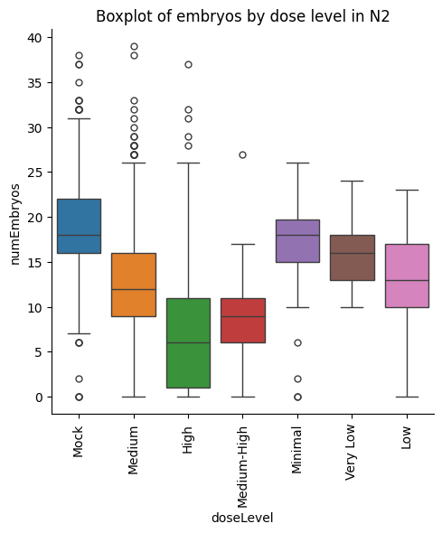

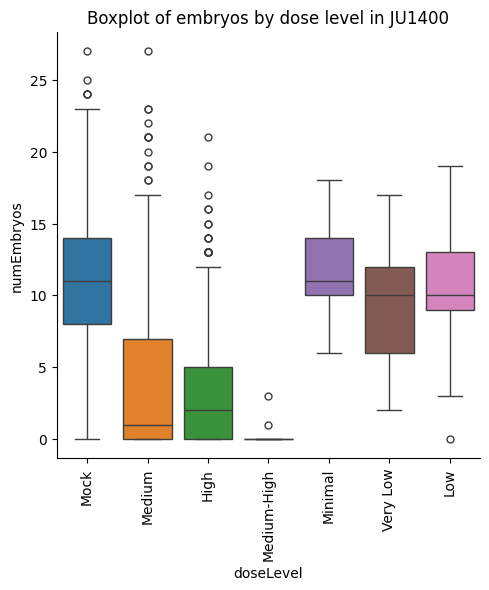

```python
# Build a for loop to print just 2 subsets of data

# What strains are we going to look at? N2 and JU1400
strain_list = ["N2", "JU1400"]

for strain in strain_list:

    # current_data = data.loc[data['wormStrain'].isin([strain]),]
    current_data = data.query('wormStrain in [@strain]')

    # Create a plot
    curr_plot = sns.catplot(data = current_data,
                            x = "doseLevel", y = "numEmbryos",
                            kind = "box",
                            height = 5, aspect = 1,
                            hue = "doseLevel"
                           )

    # Set the title of the plot
    curr_plot.set(title="Boxplot of embryos by dose level in " + strain)

    # Rotate the text
    curr_plot.set_xticklabels(rotation = 90)

    # Save the plot
    curr_plot.savefig("data/embryoBoxplot" + strain + ".png",
                      format = "png",
                      dpi = 300
                     )
```

# 4.0.0 Conditional control flow

We use the term **conditionals** to denote logical expressions that specifically evaluate to `True` or `False` and are used to determine *how* a program will run. Which set of code will it run next? Will it terminate a loop? This is where we also get the idea of flow control or control of flow.

## 4.1.0 The `if` statement executes when the conditional evaluates to `True`

The purpose of the `if` control statement is pretty clear. **If** a condition is met (`True`), **then** execute a statement. The following is the general structure of `if`:

```
if condition:
    statement
```

where `condition` can be a simple logical expression or a complex one involving many of the operators we've already covered. Note the use of *indentation* again in our code to denote what to run (when `True`)! Let's give it a try.

```python
a = 4
if a == 4:
    print('yes, a is 4')
```

```
yes, a is 4
```

```python
# Nothing will print since a = 4 from above
if a == 5:
    print('yes, a is 4')
```

### 4.1.1 The `else` statement executes when your `if` conditional evaluates to `False`

In the above code we have not set any instruction for when the condition evaluates to `False`. In that case, the `statement` line is not evaluated and therefore nothing is printed.

Think of the `else` statement much like plan B. It allows us to provide a catch-all set of code to run in the case where our conditional has "failed". Let's update our general code structure:

```
if condition:
    first_statement
else:
    second_statement
```

Simple, right?

The following code adds a boolean column called `sterile` to a subset of data called `subdata` (just for computational efficiency). Every observation (row) where the embryo count is 0 will be classified as "yes" for `sterile` and "no" otherwise.

We'll also revist or introduce two new concepts:

1. The DataFrame method `itertuples()` which returns named tuples of values from our DataFrame. It allows us to iterate over rows as named tuples where each element can be called by `.name`.
2. The Unpacking/Packing operator `*`.

### 4.1.1.1 The unpacking operator `*`

Up until now we've used this operator for *multiplication* and other purposes **BUT** when placed directly to the **left of an iterable**, it can help to *unpack* the elements for passing on as arguments for a function or passing along the elements of an iterator. Conversely, we can use it as part of a variable assignment to *pack or repack* an unspecified number of elements **into a `list` as a single variable**.

**Read more:** You can find out more about the packing and unpacking operator with this great [tutorial](https://stackabuse.com/unpacking-in-python-beyond-parallel-assignment)

Let's practice with unpacking and packing before moving forward shall we?

```python
# Make an example list
example_list = [1, 2, 3, 4, 5, 6]

# Print the list itself
print(example_list)

# Unpack and print the elements of the list in a single call
print(*example_list)
```

```
[1, 2, 3, 4, 5, 6]
1 2 3 4 5 6
```

```python
# Break the list into multiple variables
first, *rest = example_list

print("first: ", first, " vs. the rest: ", rest)
```

```
first:  1  vs. the rest:  [2, 3, 4, 5, 6]
```

```python
# Iterate through a word by unpacking it
word = 'data'
it = iter(word)
print(*it)
```

```
d a t a
```

```python
# run print(*it) again won't print anything and the it will need to be redefined in order to run print(*it) again
print(*it)
```

```python
# Uncomment this code cell if you need to restart the book!
# import pandas as pd

# data = pd.read_csv('data/embryo_long_merged.csv')

# # data = data.sort_values('count', ascending = False)
# data.head()

# # Make a copy of our DataFrame
# subdata = data.iloc[:100, :].copy()
```

### 4.1.1.2 Back to using the `else` statement

```python
# Make a copy of our DataFrame
subdata = data.iloc[:100, :].copy()

# Create a new column full of placeholder values: None, np.nan or False
subdata['sterile'] = bool()

# Set the "sterile" value row by row
for index, *row in subdata.itertuples():

    # if our embryo counts are 0 or less (-1 = males) then consider it abundant
    if subdata.loc[index, 'numEmbryos'] <= 0:
        subdata.loc[index, 'sterile'] = True

    # Otherwise it is not sterile
    else:
        subdata.loc[index, 'sterile'] = False

# Take a look at the resulting DataFrame changes
subdata.head(10)
```

|  | worm.number | date | wormStrain | pathogenStrain | pathogenDose | doseLevel | timepoint | merontsPresent | sporesPresent | numEmbryos | ... | Spores/cm2 | Temp | infection.type | Staining Date | Stain type | Slide date | Slide number | Slide Box | Imaging Date | sterile |
| --- | --- | --- | --- | --- | --- | --- | --- | --- | --- | --- | --- | --- | --- | --- | --- | --- | --- | --- | --- | --- | --- |
| 0 | 1 | 190426 | AB1 | LUAm1 | 0M | Mock | 72hpi | False | False | 10 | ... | 0.0 | 21 | continuous | 190430 | DY96 | 190501 | 7 | 2 | 190502 | False |
| 1 | 2 | 190426 | AB1 | LUAm1 | 0M | Mock | 72hpi | False | False | 9 | ... | 0.0 | 21 | continuous | 190430 | DY96 | 190501 | 7 | 2 | 190502 | False |
| 2 | 3 | 190426 | AB1 | LUAm1 | 0M | Mock | 72hpi | False | False | 16 | ... | 0.0 | 21 | continuous | 190430 | DY96 | 190501 | 7 | 2 | 190502 | False |
| 3 | 4 | 190426 | AB1 | LUAm1 | 0M | Mock | 72hpi | False | False | 13 | ... | 0.0 | 21 | continuous | 190430 | DY96 | 190501 | 7 | 2 | 190502 | False |
| 4 | 5 | 190426 | AB1 | LUAm1 | 0M | Mock | 72hpi | False | False | 8 | ... | 0.0 | 21 | continuous | 190430 | DY96 | 190501 | 7 | 2 | 190502 | False |
| 5 | 6 | 190426 | AB1 | LUAm1 | 0M | Mock | 72hpi | False | False | 13 | ... | 0.0 | 21 | continuous | 190430 | DY96 | 190501 | 7 | 2 | 190502 | False |
| 6 | 7 | 190426 | AB1 | LUAm1 | 0M | Mock | 72hpi | False | False | 18 | ... | 0.0 | 21 | continuous | 190430 | DY96 | 190501 | 7 | 2 | 190502 | False |
| 7 | 8 | 190426 | AB1 | LUAm1 | 0M | Mock | 72hpi | False | False | 18 | ... | 0.0 | 21 | continuous | 190430 | DY96 | 190501 | 7 | 2 | 190502 | False |
| 8 | 9 | 190426 | AB1 | LUAm1 | 0M | Mock | 72hpi | False | False | 10 | ... | 0.0 | 21 | continuous | 190430 | DY96 | 190501 | 7 | 2 | 190502 | False |
| 9 | 10 | 190426 | AB1 | LUAm1 | 0M | Mock | 72hpi | False | False | 16 | ... | 0.0 | 21 | continuous | 190430 | DY96 | 190501 | 7 | 2 | 190502 | False |

10 rows × 32 columns

### 4.1.2 Use the `elif` statement if you have *multiple* conditions to check

Getting the hang of `if` and `else`? Next in line is `elif`. Consider `elif` an intermediate between `if` and `else`. It's literally a portmanteau of `else` and `if` which means if you want to check for multiple possible scenarios - usually (but not necessarily) with an order of precedence, then you can use the `elif` statement to go through that checklist. Let's see how it works.

Based on the pathogen dose level, add a column called `treatment` that will either be **baseline**, **infected**, or **exluded** depending on the dose levels Mock; Medium/High; and other. We'll also skip unpacking our itertuple in favour of directly using the tuple's attributes to grab information.

Remember: if a conditional fails, the statement within it will not be executed! Once a conditional **is** triggered, the remaining conditionals **will not be checked**.

```python
# create an empty column in our subdata. It cannot be empty so we are populating it with empty strings
subdata['treatment'] = str()

# Iterate one row at a time
for row in subdata.itertuples():

    # print(row)
    # if doseLevel is Mock, then these are baseline
    if row.doseLevel == "Mock":
        # Directly set the treatment value in the corresponding row
        subdata.loc[row.Index, 'treatment'] = 'baseline'

    # Pick your infected condition
    elif (row.doseLevel in ["Medium", "High"]):
        subdata.loc[row.Index, 'treatment'] = 'infected'

    # By default remaining values are varying dose level types we may want to drop
    else:
        subdata.loc[row.Index, 'treatment'] = 'excluded'

# Check our resulting DataFrame
subdata.head()
```

|  | worm.number | date | wormStrain | pathogenStrain | pathogenDose | doseLevel | timepoint | merontsPresent | sporesPresent | numEmbryos | ... | Temp | infection.type | Staining Date | Stain type | Slide date | Slide number | Slide Box | Imaging Date | sterile | treatment |
| --- | --- | --- | --- | --- | --- | --- | --- | --- | --- | --- | --- | --- | --- | --- | --- | --- | --- | --- | --- | --- | --- |
| 0 | 1 | 190426 | AB1 | LUAm1 | 0M | Mock | 72hpi | False | False | 10 | ... | 21 | continuous | 190430 | DY96 | 190501 | 7 | 2 | 190502 | False | baseline |
| 1 | 2 | 190426 | AB1 | LUAm1 | 0M | Mock | 72hpi | False | False | 9 | ... | 21 | continuous | 190430 | DY96 | 190501 | 7 | 2 | 190502 | False | baseline |
| 2 | 3 | 190426 | AB1 | LUAm1 | 0M | Mock | 72hpi | False | False | 16 | ... | 21 | continuous | 190430 | DY96 | 190501 | 7 | 2 | 190502 | False | baseline |
| 3 | 4 | 190426 | AB1 | LUAm1 | 0M | Mock | 72hpi | False | False | 13 | ... | 21 | continuous | 190430 | DY96 | 190501 | 7 | 2 | 190502 | False | baseline |
| 4 | 5 | 190426 | AB1 | LUAm1 | 0M | Mock | 72hpi | False | False | 8 | ... | 21 | continuous | 190430 | DY96 | 190501 | 7 | 2 | 190502 | False | baseline |

5 rows × 33 columns

## 4.2.0 Use `while` loops when you want to iterate based on a condition

`while` loops run "while" a condition continues to evaluate to `True`. At the start of each loop, the condition is re-evaluated before a decision is made. If a `for` loop and an `if` statement were to make a weird code-baby, the `while` loop would be it.

You can use the conditional to iterate in different ways like:

1. Walking or moving through an iterable
2. Counting through a specific number of "successful" operations

Let's experiment with how that works shall we?

```python
# Build a list
x = [1, 2, 3, 4]

# while there is something in x
while x: # Recall: an empty object evaluates to False!
    print(x.pop(-1))

    # What is -1 doing here? Reverse indexing except pop() already uses the end to remove items.
```

```
4
3
2
1
```

```python
# Generate a counter
z = 1

# Use the counter in while loop
while z < 10:
    # print the counter value
    print(z)

    # increase z by 1 with each iteration so the loop -eventually- breaks
    z += 1
```

```
1
2
3
4
5
6
7
8
9
```

### 4.2.1 Make sure your `while` conditional can evaluate to `False`

In our first example, there is an eventual end to the list because we are permanently removing items. Therefore the conditional will evaluate to `False` when the list is empty (ie `[]`).

Our second example, however, requires us to remember to increment our variable `z`. Since this is quite a simple loop it's not an issue as we always increment the value of `z`. In other cases with complex branching code with `if` and/or `elif` statements you must be careful to check that your conditional will eventually fail.

Let's try another example where we print only those rows from `subdata` where the worm strain is to be either '*AB1*' or '*ED3042*'. We'll keep just the first 6 columns of data so it's easier to look at.

**Using booleans with DataFrame.iloc[ ]:** Last lecture we discussed filtering our data using a boolean series with *either* the **.loc** or **.iloc** methods. While you can use booleans to index with the **.iloc** method, it must be a **boolean array** of a matching index or column size. These can made from something like a **.values()** method call.

```python
# Here's the list of our criteria
strain = ['AB1', 'ED3042']

i=0

# Make a variable to hold our results
strainData_list = []

# While go through the criteria list
while i < len(strain):

    strainData_list.append(subdata.iloc[(subdata['wormStrain'] == strain[i]).values, # filter the data by strain
                                        :6]                                          # only keep the first 6 columns
                           .head() # Keep the first 5 rows
                          )
    i += 1

# print our list
strainData_list

# How long is the list?
len(strainData_list)
```

```
[   worm.number    date wormStrain pathogenStrain pathogenDose doseLevel
 0            1  190426        AB1          LUAm1           0M      Mock
 1            2  190426        AB1          LUAm1           0M      Mock
 2            3  190426        AB1          LUAm1           0M      Mock
 3            4  190426        AB1          LUAm1           0M      Mock
 4            5  190426        AB1          LUAm1           0M      Mock,
     worm.number    date wormStrain pathogenStrain pathogenDose doseLevel
 62            1  190426     ED3042          LUAm1           0M      Mock
 63            2  190426     ED3042          LUAm1           0M      Mock
 64            3  190426     ED3042          LUAm1           0M      Mock
 65            4  190426     ED3042          LUAm1           0M      Mock
 66            5  190426     ED3042          LUAm1           0M      Mock]
```

```
2
```

Now we have a list of two: "AB1" and "ED3042". We can use a `for` loop to unlist them, then use Pandas' `concat()` to join them into single data frame

```python
# Unlist into data frames and then join into a single data frame

list_b = [] # create empty list

for i in range(len(strainData_list)):

    # Pull an element from the list
    list_a = pd.DataFrame(strainData_list[i])

    # Add that element into list_b
    list_b.append(list_a)

    # Concatenate list_b to df_test
    df_test = pd.concat(list_b) # Does this belong inside or outside the loop?


# Output the data
df_test

# What is this code really doing?
```

|  | worm.number | date | wormStrain | pathogenStrain | pathogenDose | doseLevel |
| --- | --- | --- | --- | --- | --- | --- |
| 0 | 1 | 190426 | AB1 | LUAm1 | 0M | Mock |
| 1 | 2 | 190426 | AB1 | LUAm1 | 0M | Mock |
| 2 | 3 | 190426 | AB1 | LUAm1 | 0M | Mock |
| 3 | 4 | 190426 | AB1 | LUAm1 | 0M | Mock |
| 4 | 5 | 190426 | AB1 | LUAm1 | 0M | Mock |
| 62 | 1 | 190426 | ED3042 | LUAm1 | 0M | Mock |
| 63 | 2 | 190426 | ED3042 | LUAm1 | 0M | Mock |
| 64 | 3 | 190426 | ED3042 | LUAm1 | 0M | Mock |
| 65 | 4 | 190426 | ED3042 | LUAm1 | 0M | Mock |
| 66 | 5 | 190426 | ED3042 | LUAm1 | 0M | Mock |

```python
# Note, we already have a list of DataFrames so...
pd.concat(strainData_list)
```

|  | worm.number | date | wormStrain | pathogenStrain | pathogenDose | doseLevel |
| --- | --- | --- | --- | --- | --- | --- |
| 0 | 1 | 190426 | AB1 | LUAm1 | 0M | Mock |
| 1 | 2 | 190426 | AB1 | LUAm1 | 0M | Mock |
| 2 | 3 | 190426 | AB1 | LUAm1 | 0M | Mock |
| 3 | 4 | 190426 | AB1 | LUAm1 | 0M | Mock |
| 4 | 5 | 190426 | AB1 | LUAm1 | 0M | Mock |
| 62 | 1 | 190426 | ED3042 | LUAm1 | 0M | Mock |
| 63 | 2 | 190426 | ED3042 | LUAm1 | 0M | Mock |
| 64 | 3 | 190426 | ED3042 | LUAm1 | 0M | Mock |
| 65 | 4 | 190426 | ED3042 | LUAm1 | 0M | Mock |
| 66 | 5 | 190426 | ED3042 | LUAm1 | 0M | Mock |

## 4.3.0 Advance through an iterator without looping using the `next()` function

Recall from the lecture 03 appendix that for each iterator, we can use the `next()` function to retrieve the next item in the queue, recalling its place in the queue. This continues until the last element is evaluated and then the iterator is empty.

If you try to go past the last element, Python will provide a `StopIteration` error to let you know you've gone too far.

Let's practice with the `next()` function.

```python
x = [1, 2, 3]

my_iterator = iter(x)

print(my_iterator)

print(next(my_iterator))  # element position 1
print(next(my_iterator))  # element position 2
print(next(my_iterator))  # element position 3
print(next(my_iterator))  # element position 4
```

```
<list_iterator object at 0x000001DCB2D46D70>
1
2
3
```

```
---------------------------------------------------------------------------
StopIteration                             Traceback (most recent call last)
Cell In[85], line 10
      8 print(next(my_iterator))  # element position 2
      9 print(next(my_iterator))  # element position 3
---> 10 print(next(my_iterator))  # element position 4

StopIteration:
```

## 4.4.0 `break`, and `continue` can interrupt loops

Sometimes you may be looping through with a `for` or `while` loop when an unexpected condition occurs. Perhaps you wanted to error-proof your code or need to exit a loop based on internal conditions encountered while examining your data. Sometimes you may have a last-ditch conditional to prevent yourself from iterating too many times, or even endlessly.

When you need to explicitly exit a loop, you can use the `break` command. This will end the loop without further repetition.

Alternatively, you may have a long series of code that you don't want to even bother evaluating with more conditionals (to save on processing power for instance). You can end the current iteration of a loop and begin the next using the `continue` command.

Let's work through a few examples

```python
# break the loop when we see the first 'r'

for letter in 'bioinformatics':

    # Here's our conditional
    if letter == 'r':
        break

    # Print the current letter
    print ('Current Letter :', letter)
```

```
Current Letter : b
Current Letter : i
Current Letter : o
Current Letter : i
Current Letter : n
Current Letter : f
Current Letter : o
```

```python
# This example breaks when var is equal to 5
var = 10

while var > 0:
    # Print the current value of var
    print ('Current variable value :', str(var))

    # Decrement var by 1
    var = var - 1

    # Here's our conditional!
    if var == 5:
        break

print("Done!")
```

```
Current variable value : 10
Current variable value : 9
Current variable value : 8
Current variable value : 7
Current variable value : 6
Done!
```

```python
# An example of how to use continue

var = 10

while var > 0:

    # decrement your variable first
    var += -1

    # Was the number even or odd?
    if (var) % 2 == 1:
        continue

    # only print even numbers
    print ('Current variable value: ', str(var))
```

```
Current variable value:  8
Current variable value:  6
Current variable value:  4
Current variable value:  2
Current variable value:  0
```

## Answer:

| That's right, you can nest control statements inside control statements of any kind really... |
| --- |

# 5.0.0 Class summary

That's our fifth class on Python! You've made it through and we've learned about a number of logical expression operators and how to apply them in loops and filtering data:

1. Flow control
2. Logical, conditional, and comparison operators
3. For loops
4. Conditional control flow

## 5.1.0 Submit your completed skeleton notebook (2% of final grade)

At the end of this lecture a Quercus assignment portal will be available to submit your completed skeletons from today (including the comprehension question answers!). These will be due one week later, before the next lecture. Each lecture skeleton is worth 2% of your final grade but a **bonus 0.5%** will also be awarded for submissions made within 24 hours from the end of lecture (ie 1600 hours the following day).

## 5.2.0 Post-lecture DataCamp assessment (5% of final grade)

Soon after the end of this lecture, a homework assignment will be available for you in [DataCamp](https://www.datacamp.com/). Your assignment is to complete chapters 3-5 (Logic, Control Flow and Filter, 1500 possible points; Loops, 1500 possible points; and Case Study, 1200 possible points) from the Intermediate Python course. This is a pass-fail assignment, and in order to pass you need to achieve a least 3150 points (75%) of the total possible points. Note that when you take hints from the DataCamp chapter, it will reduce your total earned points for that chapter.

You may need to take several screenshots if you cannot print it all in a single try. Submit the file(s) or a combined PDF for the homework to the assignment portal on Quercus. By submitting your scores for each section, and chapter, we can keep track of your progress, identify knowledge gaps, and produce a standardized way for you to check on your assignment "grades" throughout the course.

You will have until 12:59 hours on Thursday, February 15th to submit your assignment (right before the next lecture).

[output not shown]

## 5.3.0 Acknowledgements

**Revision 1.0.0**: materials prepared by Oscar Montoya, M.Sc. *Bioinformatician, Education and Outreach, CAGEF.*

**Revision 1.1.0**: edited and prepared for **CSB1021H S LEC0140**, 06-2021 by Calvin Mok, Ph.D. *Bioinformatician, Education and Outreach, CAGEF.*

**Revision 1.2.0**: edited and prepared for **CSB1021H S LEC0140**, 01-2022 by Calvin Mok, Ph.D. *Bioinformatician, Education and Outreach, CAGEF.*

**Revision 1.2.1**: edited and prepared for **CSB1021H S LEC0140**, 01-2023 by Calvin Mok, Ph.D. *Bioinformatician, Education and Outreach, CAGEF.*

**Revision 1.2.2**: edited and prepared for **CSB1021H S LEC0140**, 01-2024 by Calvin Mok, Ph.D. *Bioinformatician, Education and Outreach, CAGEF.*

## 5.4.0 Resources

- https://www.edx.org/course/python-data-structures
- https://docs.scipy.org/doc/numpy-1.13.0/reference/arrays.nditer.html
- https://www.w3schools.com/python/python_for_loops.asp
- https://www.tutorialspoint.com/python/python_for_loop.htm

# 6.0.0 Appendix 1: More on looping

## 6.1.0 Iterating through dictionaries

Recall that dictionaries consist of `key:value` pairs and that unlike lists, they have no index. Instead, they are accessed by providing a matching `key`. When we provide a `dictionary` object to a `for` loop it will return an iterator to its hash/`keys`.

Let's revisit our amino acid dictionary from lecture 2.

```python
dictionary_aminoacids = {"Alanine": {"Ala", "A",  "GCA GCC GCG GCT"},
                         "Cysteine": {"Cys", "C", "TGC, TGT"},
                         "Aspartic acid": {"Asp", "D", "GAC GAT"},
                         "Glutamic acid": {"Glu", "E", "GAA GAG"},
                         "Phenylalanine": {"Phe", "F", "TTC TTT"},
                         "Glycine": {"Gly", "G", "GGA GGC GGG GGT"},
                         "Histidine": {"His", "H", "CAC CAT"},
                         "Isoleucine": {"Ile", "I", "ATA ATC ATT"},
                         "Lysine": {"Lys", "K", "AAA AAG"},
                         "Leucine": {"Leu", "L", "TTA TTG CTA CTC CTG CTT"},
                         "Methionine": {"Met", "M" "ATG"},
                         "Asparagine": {"Asn", "N", "AAC AAT"},
                         "Proline": {"Pro", "P", "CCA CCC CCG CCT"},
                         "Glutamine": {"Gln", "Q", "CAA CAG"},
                         "Arginine": {"Arg", "R", "AGA AGG CGA CGC CGG CGT"},
                         "Serine": {"Ser", "S", "AGC AGT TCA TCC TCG TCT"},
                         "Threonine": {"Thr", "T", "ACA ACC ACG ACU"},
                         "Valine": {"Val", "V", "GTA GTC GTG GTT"},
                         "Tryptophan": {"Trp", "W", "TGG"},
                         "Tyrosine": {"Tyr", "Y," "TAC TAT"}
                        }
```

```python
# Supplying a dictionary will iterate through its hash

for aminoacid in dictionary_aminoacids:
    print(aminoacid)
```

### 6.1.1 Iterate through your dictionary values by indexing with the hash

Now that we know we can get the `key` information in our `for` loop, we can use that much like we did with our list examples to iterate through the `value` information stored in the dictionary.

```python
# Provide the hash back to your dictionary
for aminoacid in dictionary_aminoacids:
    print(aminoacid,"::",dictionary_aminoacids[aminoacid])
```

### 6.1.2 Use the attributes of a dictionary as an iterator

Like the dictionary, you can also iterate through its attributes like the keys and values. Remember that we can use methods from the dictionary object to return this information for us. There are three methods we can use for this purpose: `keys()`, `values()`, and `items()`.

```python
# equivalent to providing just the dictionary object
for aminoacid in dictionary_aminoacids.keys():
    print(aminoacid,"::",dictionary_aminoacids[aminoacid])
```

```python
# Retrieve the values as an iterator
for info in dictionary_aminoacids.values():
    print(info)
```

Or get the whole dictionary

```python
# Retrive the key:value pairs as an iterator
for info in dictionary_aminoacids.items():
    print(info)
```

Each key:value pair is printed as a tuple.

```python
# What type of object is returned by dictionary.items()?
type(dictionary_aminoacids.items())

# What type of object is a single dictionary item?
type(list(dictionary_aminoacids.items())[0])
```

```python
# The above code is to some extent equivalent to
# Retrive the key:value pairs as an iterator
for info in dictionary_aminoacids.items():
    # Subset the tuple into its two components
    print(info[0], "::", info[1])
```

### 6.1.3 Use the `for` loop to assign multiple variables from your iterator

Knowing that the `item()` method returns a `tuple` object from our dictionary - specifically with two elements, can we take advantage of that information? Rather than index the information from the tuple, let's try to assign multiple variables to the elements from our tuple with the `for` loop itself.

```python
# Assign both a key and value from the each value in our iterator
for (key, value) in dictionary_aminoacids.items():
    print(key, "::", value)
```

```python
# What if we assign multiple values?
for (key, value, extra) in dictionary_aminoacids.items():
    print(key, "::", value)
```

## 6.2.0 Iterating through Numpy 2D-arrays using `nditer()`

From our previous examples with arrays, it looks like iterating through a 1D array seems pretty straight-forward. Iteration over 2D Numpy arrays, however, is slightly more complex than with 1D counterparts if you are re-arranging it on the fly.

*"An important thing to be aware of for this iteration is that the order is chosen to match the memory layout of the array instead of using a standard C or Fortran ordering. This is done for access efficiency, reflecting the idea that by default one simply wants to visit each element without concern for a particular ordering. We can see this by iterating over the transpose of our previous array, compared to taking a copy of that transpose in C order."* https://docs.scipy.org/doc/numpy-1.13.0/reference/arrays.nditer.html

What does all that mean? In simpler terms the iterator for an array uses the same order as it is *stored in memory* regardless of the shape the array may be in. Let's see how that plays out in practice

```python
# Generate a 2x3 array
array_5 = np.array([[6, 7, 8],
                    [9, 10, 11]])

for x in np.nditer(array_5):
    print(x)
```

```python
# What does the transpose look like?
array_5.T

# How does that affect the iterator?
for x in np.nditer(array_5.T):
    print(x)
```

```python
# Use a copy of the transpose
for x in np.nditer(array_5.T.copy()):
    print("transpose: ", x)
```

### 6.2.1 Use the `order` parameter to override how iterator elements are made in `nditer()`

You don't necessarily want to copy your objects every time you want to move through them after transposing or reshaping them. Instead you should look to the specific parameters of `nditer()` of which include the `order` parameter which takes on the values of:

- `C`: C order, traverse horizontally.
- `F`: Fortran order, traverse vertically.
- `A`: Fortran order if all the arrays are Fortran contiguous; C order otherwise.
- `K`: As close to the order array elements appear in memory as possible (keep existing order, default behaviour)

**Read more:** For more information on this parameter check out the [documentation](https://docs.scipy.org/doc/numpy-1.13.0/reference/arrays.nditer.html)

```python
# Bring up array_5
array_5

# Fortran language order
for x in np.nditer(array_5, order='F'):
    print(x, end=' ')
```

```python
# Bring up array_5
array_5

# C language order
for x in np.nditer(array_5, order='C'):
    print(x, end=' ')
```

```python
# Look to a larger array
array_3.T

# Keep array order as it was when the array was created
for x in np.nditer(array_3.T, order='K'):
    print(x, end=' ')
```

# 7.0.0 Appendix 2: Subsetting `DataFrames`

Below you'll find some example code for subsetting DataFrame objects. Recall some of our rules involving subsetting `DataFrame` objects include:

1. Using a list to subset one or more columns returns a `DataFrame`.
2. The `loc[]` and `iloc[]` methods can be used to subset both a `row` and `column` range, both of which are also amenable to slicing notation.
3. The `loc[]` and `iloc[]` methods accept boolean `Series` or conditional expressions or a mixture of both. All `Series` and expressions must have the same number of elements as there are rows in the `DataFrame`.
4. `DataFrames` can be subset through a series of chain indexing ie `[row][col][conditional_expression]` but you will be returned a copy of the data and not access to the original.

```python
import pandas as pd

# Read in subset_taxa_metdata_merged.csv
data = pd.read_csv('data/embryo_long_merged.csv')
data.head()
data.info()
```

```python
# select based on row and column names
data.loc[:6,['wormStrain']]
```

```python
# select based on row and column indices
data.iloc[ :6 , [7]]

# Note how many rows we get back compared to loc[]
```

```python
# call GENUS as an attribute of the data frame
data.wormStrain[0:6]
```

```python
# Chain-indexing by retrieving a column and then selecting rows
data[['wormStrain']][0:6]
```

```python
# slice of rows 0 to 4. No similar option available to subset columns
data[0:5]
```

```python
# Use a logical expression to retrieve rows with count > 16
data.loc[(data["numEmbryos"] > 16)][['wormStrain']]
```

```python
# Chain-index a logical, then pull a column, then specify rows
data.loc[(data.numEmbryos < 2)]["wormStrain"].iloc[0:6]
```

From above, you can only call on columns as attributes with `.` notation if their names conform to the following rules:

1. No spaces
2. Cannot begin with a number or special character

If you can't access via dot notation, you can use simple indexing with `['colName']` instead, which offers more flexibility in your column names.

```python
# this time it works by slightly changing the syntax
data.loc[(data['numEmbryos'] < 2)]['wormStrain'].iloc[:6]

# Try to multi-index to select
data.loc[(data['numEmbryos'] < 2), 'wormStrain'].iloc[:6]
```

## The Center for the Analysis of Genome Evolution and Function (CAGEF)

The Centre for the Analysis of Genome Evolution and Function (CAGEF) at the University of Toronto offers comprehensive experimental design, research, and analysis services in microbiome and metagenomic studies, genomics, proteomics, and bioinformatics.

From targeted DNA amplicon sequencing to transcriptomes, whole genomes, and metagenomes, from protein identification to post-translational modification, CAGEF has the tools and knowledge to support your research. Our state-of-the-art facility and experienced research staff provide a broad range of services, including both standard analyses and techniques developed by our team. In particular, we have special expertise in microbial, plant, and environmental systems.

For more information about us and the services we offer, please visit https://www.cagef.utoronto.ca/.

[figure not shown]